# Final Project — Nonlinear Model Analysis

Jakes Chege

2026-06-03

```r
pkgs <- c("tidyverse", "caret", "randomForest", "xgboost", "nnet",
          "mgcv", "splines", "corrplot", "ggplot2", "dplyr",
          "pdp", "vip", "readxl", "rpart", "rpart.plot", "earth")

lapply(pkgs, library, character.only = TRUE)
```

[output not shown]

[output cut: 103 more lines]

```r
img_dir <- "/home/jakes/Documents/strathmore/Modules/Module 3/linear_models/classwork/final_project/markdowns/images"
dir.create(img_dir, showWarnings = FALSE, recursive = TRUE)
```

# 1 Load Data from EDA Output

We load the post-EDA Excel file produced at the end of `EDA.Rmd`. This file already has renamed columns, factor variants (`_f`), and an `is_outlier` flag column.

```r
df <- read_excel("~/Documents/strathmore/Modules/Module 3/linear_models/classwork/final_project/markdowns/new_data/ENB2012_post_EDA.xlsx")
```

```r
cat("Dimensions:", nrow(df), "rows x", ncol(df), "columns\n")
```

```
## Dimensions: 768 rows x 15 columns
```

```r
cat("Columns:", paste(names(df), collapse = ", "), "\n\n")
```

```
## Columns: RelCompactness, SurfaceArea, WallArea, RoofArea, OverallHeight, Orientation, GlazingArea, GlazingAreaDist, HeatingLoad, CoolingLoad, Orientation_f, OverallHeight_f, GlazingArea_f, GlazingAreaDist_f, is_outlier
```

```r
glimpse(df)
```

```
## Rows: 768
## Columns: 15
## $ RelCompactness    <dbl> 0.98, 0.98, 0.98, 0.98, 0.90, 0.90, 0.90, 0.90, 0.86…
## $ SurfaceArea       <dbl> 514.5, 514.5, 514.5, 514.5, 563.5, 563.5, 563.5, 563…
## $ WallArea          <dbl> 294.0, 294.0, 294.0, 294.0, 318.5, 318.5, 318.5, 318…
## $ RoofArea          <dbl> 110.25, 110.25, 110.25, 110.25, 122.50, 122.50, 122.…
## $ OverallHeight     <dbl> 7.0, 7.0, 7.0, 7.0, 7.0, 7.0, 7.0, 7.0, 7.0, 7.0, 7.…
## $ Orientation       <dbl> 2, 3, 4, 5, 2, 3, 4, 5, 2, 3, 4, 5, 2, 3, 4, 5, 2, 3…
## $ GlazingArea       <dbl> 0, 0, 0, 0, 0, 0, 0, 0, 0, 0, 0, 0, 0, 0, 0, 0, 0, 0…
## $ GlazingAreaDist   <dbl> 0, 0, 0, 0, 0, 0, 0, 0, 0, 0, 0, 0, 0, 0, 0, 0, 0, 0…
## $ HeatingLoad       <dbl> 15.55, 15.55, 15.55, 15.55, 20.84, 21.46, 20.71, 19.…
## $ CoolingLoad       <dbl> 21.33, 21.33, 21.33, 21.33, 28.28, 25.38, 25.16, 29.…
## $ Orientation_f     <chr> "2", "3", "4", "5", "2", "3", "4", "5", "2", "3", "4…
## $ OverallHeight_f   <chr> "High_7m", "High_7m", "High_7m", "High_7m", "High_7m…
## $ GlazingArea_f     <chr> "0", "0", "0", "0", "0", "0", "0", "0", "0", "0", "0…
## $ GlazingAreaDist_f <chr> "0", "0", "0", "0", "0", "0", "0", "0", "0", "0", "0…
## $ is_outlier        <lgl> FALSE, FALSE, FALSE, FALSE, FALSE, FALSE, FALSE, FAL…
```

# 2 Restore Factor Variables

Excel does not preserve R factor types. We restore them from the raw numeric columns that were carried over.

```r
df$Orientation_f <- factor(
  df$Orientation,
  levels = 2:5,
  labels = c("N", "E", "S", "W")
)

df$OverallHeight_f <- factor(
  df$OverallHeight,
  levels = c(3.5, 7.0),
  labels = c("Low_3.5m", "High_7m")
)

df$GlazingArea_f <- factor(
  df$GlazingArea,
  levels = c(0, 0.1, 0.25, 0.4),
  labels = c("None", "Low_10pct", "Med_25pct", "High_40pct")
)

df$GlazingAreaDist_f <- factor(
  df$GlazingAreaDist,
  levels = 0:5,
  labels = c("None", "Uniform", "N_heavy", "E_heavy", "S_heavy", "W_heavy")
)

cat("Factor levels restored:\n")
```

```
## Factor levels restored:
```

```r
cat("  Orientation_f    :", levels(df$Orientation_f), "\n")
```

```
##   Orientation_f    : N E S W
```

```r
cat("  OverallHeight_f  :", levels(df$OverallHeight_f), "\n")
```

```
##   OverallHeight_f  : Low_3.5m High_7m
```

```r
cat("  GlazingArea_f    :", levels(df$GlazingArea_f), "\n")
```

```
##   GlazingArea_f    : None Low_10pct Med_25pct High_40pct
```

```r
cat("  GlazingAreaDist_f:", levels(df$GlazingAreaDist_f), "\n")
```

```
##   GlazingAreaDist_f: None Uniform N_heavy E_heavy S_heavy W_heavy
```

# 3 Outlier Handling

The `is_outlier` flag was computed in EDA using the IQR method across all numeric predictors and responses. We inspect the flagged rows and decide on a strategy.

## 3.1 Inspect flagged rows

```r
cat("Total rows flagged as outliers:", sum(df$is_outlier, na.rm = TRUE), "\n")
```

```
## Total rows flagged as outliers: 0
```

```r
cat("Percentage:", round(mean(df$is_outlier, na.rm = TRUE) * 100, 2), "%\n\n")
```

```
## Percentage: 0 %
```

```r
# Preview flagged rows
df %>%
  filter(is_outlier == TRUE) %>%
  dplyr::select(RelCompactness:CoolingLoad) %>%
  summary()
```

```
##  RelCompactness  SurfaceArea     WallArea      RoofArea   OverallHeight
##  Min.   : NA    Min.   : NA   Min.   : NA   Min.   : NA   Min.   : NA
##  1st Qu.: NA    1st Qu.: NA   1st Qu.: NA   1st Qu.: NA   1st Qu.: NA
##  Median : NA    Median : NA   Median : NA   Median : NA   Median : NA
##  Mean   :NaN    Mean   :NaN   Mean   :NaN   Mean   :NaN   Mean   :NaN
##  3rd Qu.: NA    3rd Qu.: NA   3rd Qu.: NA   3rd Qu.: NA   3rd Qu.: NA
##  Max.   : NA    Max.   : NA   Max.   : NA   Max.   : NA   Max.   : NA
##   Orientation   GlazingArea  GlazingAreaDist  HeatingLoad   CoolingLoad
##  Min.   : NA   Min.   : NA   Min.   : NA     Min.   : NA   Min.   : NA
##  1st Qu.: NA   1st Qu.: NA   1st Qu.: NA     1st Qu.: NA   1st Qu.: NA
##  Median : NA   Median : NA   Median : NA     Median : NA   Median : NA
##  Mean   :NaN   Mean   :NaN   Mean   :NaN     Mean   :NaN   Mean   :NaN
##  3rd Qu.: NA   3rd Qu.: NA   3rd Qu.: NA     3rd Qu.: NA   3rd Qu.: NA
##  Max.   : NA   Max.   : NA   Max.   : NA     Max.   : NA   Max.   : NA
```

Since there are no outliers, we keep the data as it is.

# 4 Response Variable Transformation

## 4.1 Visual check: raw vs log

```r
png(file.path(img_dir, "response_raw_vs_log.png"), width = 1200, height = 900, res = 150)
par(mfrow = c(2, 2))

hist(df$HeatingLoad,      breaks = 30, col = "lightblue",
     main = "Y1: Heating Load (raw)", xlab = "HeatingLoad")
hist(log(df$HeatingLoad), breaks = 30, col = "lightgreen",
     main = "log(Y1): Heating Load",  xlab = "log(HeatingLoad)")

hist(df$CoolingLoad,      breaks = 30, col = "lightblue",
     main = "Y2: Cooling Load (raw)", xlab = "CoolingLoad")
hist(log(df$CoolingLoad), breaks = 30, col = "lightgreen",
     main = "log(Y2): Cooling Load",  xlab = "log(CoolingLoad)")

par(mfrow = c(1, 1))
dev.off()
```

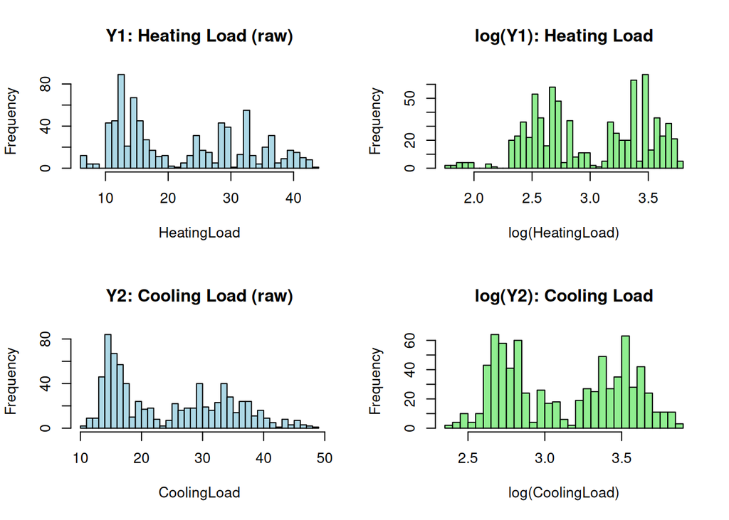

```r
# Render inline as well
par(mfrow = c(2, 2))
hist(df$HeatingLoad,      breaks = 30, col = "lightblue",
     main = "Y1: Heating Load (raw)", xlab = "HeatingLoad")
hist(log(df$HeatingLoad), breaks = 30, col = "lightgreen",
     main = "log(Y1): Heating Load",  xlab = "log(HeatingLoad)")
hist(df$CoolingLoad,      breaks = 30, col = "lightblue",
     main = "Y2: Cooling Load (raw)", xlab = "CoolingLoad")
hist(log(df$CoolingLoad), breaks = 30, col = "lightgreen",
     main = "log(Y2): Cooling Load",  xlab = "log(CoolingLoad)")
```

```r
par(mfrow = c(1, 1))
```

# 5 Multicollinearity & VIF Review

SurfaceArea was found in EDA to be perfectly collinear with WallArea + RoofArea. We drop it from the modelling set and confirm VIF scores are acceptable for the remaining predictors.

```r
vif_model <- lm(
  HeatingLoad ~ RelCompactness + WallArea + RoofArea +
                OverallHeight + Orientation + GlazingArea + GlazingAreaDist,
  data = df
)

vif_vals <- car::vif(vif_model)

vif_table <- data.frame(
  Variable = names(vif_vals),
  VIF      = round(vif_vals, 3),
  Flag     = ifelse(vif_vals > 10, "HIGH — consider dropping",
             ifelse(vif_vals > 5,  "Moderate — monitor", "OK"))
)

print(vif_table)
```

```
##                        Variable     VIF                     Flag
## RelCompactness   RelCompactness 105.524 HIGH — consider dropping
## WallArea               WallArea  27.663 HIGH — consider dropping
## RoofArea               RoofArea 211.938 HIGH — consider dropping
## OverallHeight     OverallHeight  31.205 HIGH — consider dropping
## Orientation         Orientation   1.000                       OK
## GlazingArea         GlazingArea   1.048                       OK
## GlazingAreaDist GlazingAreaDist   1.048                       OK
```

We will keep them all, and accept the VIF. This is because Random Forest, XGBoost, and GAMs are not affected by multicollinearity at all. High VIF only damages OLS coefficient interpretation, not prediction accuracy.

# 6 Polynomial Relationship Check (all predictors)

We extend the single-predictor check to cover all continuous predictors against both outcomes, so we know which quadratic terms are worth including as engineered features.

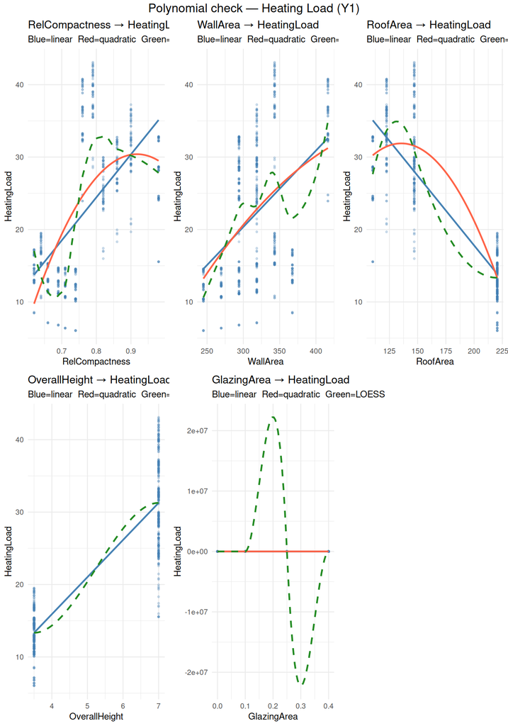

```r
cont_preds <- c("RelCompactness", "WallArea", "RoofArea",
                "OverallHeight", "GlazingArea")

make_poly_plots <- function(response_var, point_col) {
  lapply(cont_preds, function(v) {
    ggplot(df, aes(x = .data[[v]], y = .data[[response_var]])) +
      geom_point(alpha = 0.25, size = 0.7, color = point_col) +
      geom_smooth(method = "lm",  formula = y ~ x,
                  color = "steelblue", se = FALSE, linewidth = 0.8) +
      geom_smooth(method = "lm",  formula = y ~ poly(x, 2),
                  color = "tomato", se = FALSE, linewidth = 0.8) +
      geom_smooth(method = "loess",
                  color = "forestgreen", se = FALSE,
                  linewidth = 0.8, linetype = "dashed") +
      labs(title = paste(v, "→", response_var),
           subtitle = "Blue=linear  Red=quadratic  Green=LOESS",
           x = v, y = response_var) +
      theme_minimal(base_size = 9)
  })
}

p_y1 <- make_poly_plots("HeatingLoad", "steelblue")
poly_y1_plot <- do.call(gridExtra::grid.arrange, c(p_y1, ncol = 3,
  list(top = "Polynomial check — Heating Load (Y1)")))
```

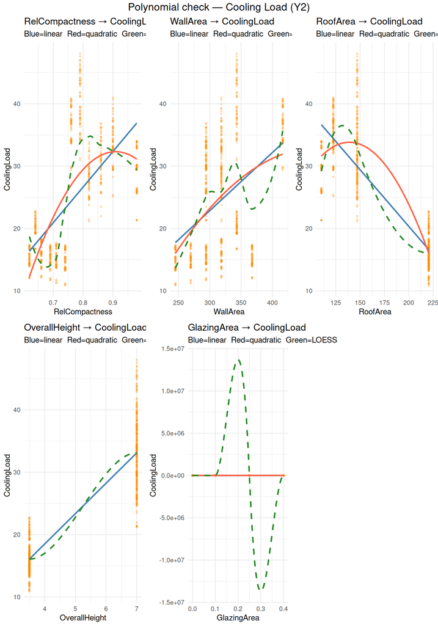

```r
ggsave(file.path(img_dir, "poly_check_heating_load.png"),
       plot = poly_y1_plot, width = 14, height = 10, dpi = 150)

p_y2 <- make_poly_plots("CoolingLoad", "darkorange")
poly_y2_plot <- do.call(gridExtra::grid.arrange, c(p_y2, ncol = 3,
  list(top = "Polynomial check — Cooling Load (Y2)")))
```

```r
ggsave(file.path(img_dir, "poly_check_cooling_load.png"),
       plot = poly_y2_plot, width = 14, height = 10, dpi = 150)
```

# 7 Feature Engineering

## 7.1 Interaction and ratio features

Physically motivated engineered features based on the scatter plots and domain interpretation from EDA.

```r
df_clean <- df %>%
  mutate(
    # --- Original four from preprocessing.Rmd ---
    CompactnessXHeight  = RelCompactness * OverallHeight,
    WallToRoofRatio     = WallArea / RoofArea,
    GlazingXCompactness = GlazingArea * RelCompactness,
    SurfToVol           = SurfaceArea / (WallArea + RoofArea),

    # --- Additional physically motivated features ---
    GlazingXHeight      = GlazingArea * OverallHeight,
    # Tall buildings with more glazing lose/gain disproportionately more heat

    WallXGlazing        = WallArea * GlazingArea,
    # Interaction between exposed wall and window area

    CompactnessSquared  = RelCompactness^2,
    # Captures the nonlinear compactness-load relationship seen in poly plots

    HeightSquared       = OverallHeight^2,
    # OverallHeight is binary (3.5 / 7.0) so this is less critical,
    # but retained for completeness in polynomial model pipelines

    GlazingToWall       = GlazingArea / (WallArea + 1),
    # Facade transparency ratio: proportion of wall that is glass

    EnvelopeArea        = WallArea + RoofArea,
    # Total heat-exchange envelope (SurfaceArea minus floor, approx)

    WallPerHeight       = WallArea / (OverallHeight + 1)
    # Normalised wall exposure per unit height
  )

cat("New features added. Total columns now:", ncol(df_clean), "\n")
```

```
## New features added. Total columns now: 26
```

```r
cat("Engineered feature names:\n")
```

```
## Engineered feature names:
```

```r
cat(paste(" -",
  c("CompactnessXHeight","WallToRoofRatio","GlazingXCompactness",
    "SurfToVol","GlazingXHeight","WallXGlazing",
    "CompactnessSquared","HeightSquared","GlazingToWall",
    "EnvelopeArea","WallPerHeight")), sep = "\n")
```

```
##  - CompactnessXHeight
##  - WallToRoofRatio
##  - GlazingXCompactness
##  - SurfToVol
##  - GlazingXHeight
##  - WallXGlazing
##  - CompactnessSquared
##  - HeightSquared
##  - GlazingToWall
##  - EnvelopeArea
##  - WallPerHeight
```

```r
library(car)
```

```r
candidate_features_clean3 <- c(
  "CompactnessXHeight",  # best single summary of shape x height
  "WallToRoofRatio",     # best single summary of envelope geometry
  "GlazingXHeight",      # glazing penalty amplified by height
  "CompactnessSquared"   # captures the nonlinear compactness curve
)

vif_model_y2d <- lm(
  CoolingLoad ~ .,
  data = df_clean[, c(candidate_features_clean3, "CoolingLoad")]
)

vif_values <- vif(vif_model_y2d)
print(sort(vif_values, decreasing = TRUE))
```

```
## CompactnessXHeight CompactnessSquared    WallToRoofRatio     GlazingXHeight
##          16.058438           8.534435           4.086935           1.309201
```

```r
candidate_features_final <- c(
  "CompactnessSquared",  # captures nonlinear compactness effect
  "WallToRoofRatio",     # envelope geometry
  "GlazingXHeight"       # glazing x height interaction
)

vif_model_y2e <- lm(
  CoolingLoad ~ .,
  data = df_clean[, c(candidate_features_final, "CoolingLoad")]
)

vif_values <- vif(vif_model_y2e)
print(sort(vif_values, decreasing = TRUE))
```

```
##    WallToRoofRatio CompactnessSquared     GlazingXHeight
##           1.660566           1.626339           1.258016
```

```r
library(glmnet)
```

```r
# Final feature set
final_features <- c(
  "CompactnessSquared",
  "WallToRoofRatio",
  "GlazingXHeight"
)

# Prepare matrices
set.seed(42)
train_idx <- sample(nrow(df_clean), 0.8 * nrow(df_clean))

X_train <- as.matrix(df_clean[train_idx, final_features])
X_test  <- as.matrix(df_clean[-train_idx, final_features])
y_train <- df_clean$CoolingLoad[train_idx]
y_test  <- df_clean$CoolingLoad[-train_idx]

# Cross-validated Elastic Net
cv_fit_y2 <- cv.glmnet(X_train, y_train, alpha = 0.5, nfolds = 10)

png(file.path(img_dir, "elastic_net_cv_preliminary.png"), width = 900, height = 700, res = 150)
plot(cv_fit_y2)
dev.off()
```

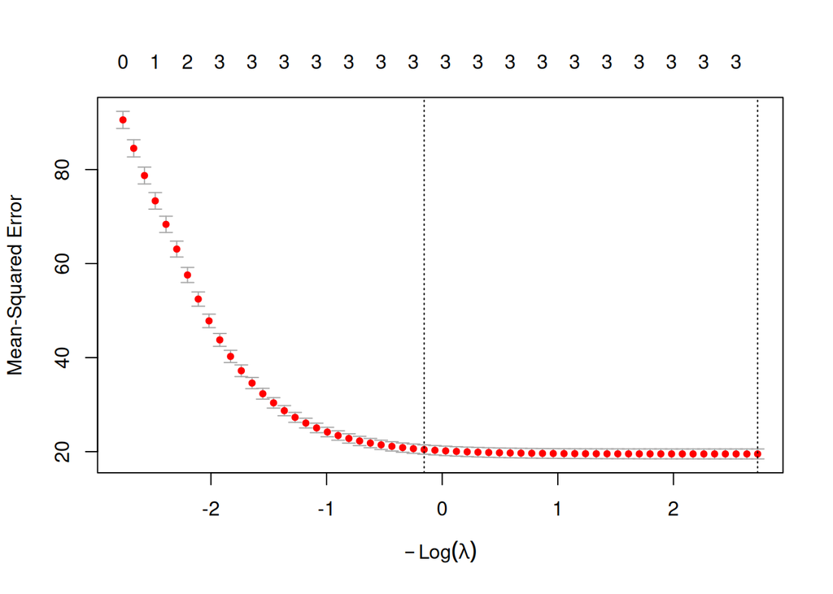

```r
plot(cv_fit_y2)
```

```r
# Best lambda
cat("Best lambda (min):", cv_fit_y2$lambda.min, "\n")
```

```
## Best lambda (min): 0.06534989
```

```r
# Coefficients
cat("\nModel coefficients:\n")
```

```
##
## Model coefficients:
```

```r
print(coef(cv_fit_y2, s = "lambda.min"))
```

```
## 4 x 1 sparse Matrix of class "dgCMatrix"
##                    lambda.min
## (Intercept)         -1.186712
## CompactnessSquared   6.682713
## WallToRoofRatio      9.061205
## GlazingXHeight       3.370301
```

```r
# Predictions and evaluation
preds <- predict(cv_fit_y2, newx = X_test, s = "lambda.min")

rmse <- sqrt(mean((y_test - preds)^2))
mae  <- mean(abs(y_test - preds))
ss_res <- sum((y_test - preds)^2)
ss_tot <- sum((y_test - mean(y_train))^2)
r2   <- 1 - ss_res / ss_tot

cat("\n--- Test Set Performance ---\n")
```

```
##
## --- Test Set Performance ---
```

```r
cat("RMSE:", round(rmse, 3), "\n")
```

```
## RMSE: 4.16
```

```r
cat("MAE: ", round(mae,  3), "\n")
```

```
## MAE:  2.95
```

```r
cat("R2:  ", round(r2,   3), "\n")
```

```
## R2:   0.808
```

## 7.2 Correlation of engineered features with outcomes

Quick screen to confirm the new features are informative before they enter modelling.

```r
eng_features <- c(
  "CompactnessXHeight","WallToRoofRatio","GlazingXCompactness",
  "SurfToVol","GlazingXHeight","WallXGlazing",
  "CompactnessSquared","GlazingToWall","EnvelopeArea","WallPerHeight"
)

cor_eng <- df_clean %>%
  dplyr::select(all_of(eng_features), HeatingLoad, CoolingLoad) %>%
  cor(use = "complete.obs")

# Show only correlations with the two outcomes
cor_with_outcomes <- data.frame(
  Feature         = eng_features,
  Cor_HeatingLoad = round(cor_eng[eng_features, "HeatingLoad"], 3),
  Cor_CoolingLoad = round(cor_eng[eng_features, "CoolingLoad"], 3)
) %>%
  arrange(desc(abs(Cor_HeatingLoad)))

print(cor_with_outcomes)
```

```
##                                 Feature Cor_HeatingLoad Cor_CoolingLoad
## SurfToVol                     SurfToVol          -0.866          -0.856
## WallToRoofRatio         WallToRoofRatio           0.845           0.831
## CompactnessXHeight   CompactnessXHeight           0.830           0.837
## WallPerHeight             WallPerHeight          -0.685          -0.705
## GlazingXHeight           GlazingXHeight           0.678           0.624
## CompactnessSquared   CompactnessSquared           0.603           0.613
## GlazingXCompactness GlazingXCompactness           0.416           0.357
## WallXGlazing               WallXGlazing           0.369           0.301
## EnvelopeArea               EnvelopeArea          -0.360          -0.385
## GlazingToWall             GlazingToWall           0.152           0.098
```

The top three features, SurfToVol, WallToRoofRatio, and CompactnessXHeight, act as the primary drivers, all demonstrating high-impact correlations exceeding 0.80 for both heating and cooling outcomes. The consistent magnitude across both targets implies that these predictors capture fundamental geometric properties that affect thermal efficiency regardless of whether the goal is heating or cooling.

The mid-tier group, led by WallPerHeight and GlazingXHeight, provides secondary stability with correlations in the 0.60–0.70 range, ensuring the model incorporates localized architectural details beyond raw proportions. Meanwhile, the lower-tier features like EnvelopeArea and GlazingToWall show notably weaker or negligible associations, suggesting they contribute minimal signal and might be candidates for dimensionality reduction or pruning. Overall, the model benefits from a “distributed load” of information rather than relying on a single, isolated variable, which typically improves generalization.

# 8 Train / Test Split

The split is done **before** scaling. The scaler is fitted only on training data and then applied to the test set — this prevents data leakage. We stratify on `OverallHeight_f` because it is the most dominant predictor identified in EDA.

```r
set.seed(42)

train_idx <- caret::createDataPartition(
  df_clean$OverallHeight_f,
  p    = 0.80,
  list = FALSE
)

df_train <- df_clean[ train_idx, ]
df_test  <- df_clean[-train_idx, ]

cat("Training set:", nrow(df_train), "rows\n")
```

```
## Training set: 616 rows
```

```r
cat("Test set    :", nrow(df_test),  "rows\n")
```

```
## Test set    : 152 rows
```

```r
# Confirm stratification held
cat("\nOverallHeight distribution — train:\n")
```

```
##
## OverallHeight distribution — train:
```

```r
print(prop.table(table(df_train$OverallHeight_f)))
```

```
##
## Low_3.5m  High_7m
##      0.5      0.5
```

```r
cat("\nOverallHeight distribution — test:\n")
```

```
##
## OverallHeight distribution — test:
```

```r
print(prop.table(table(df_test$OverallHeight_f)))
```

```
##
## Low_3.5m  High_7m
##      0.5      0.5
```

```r
eval_reg <- function(actual, predicted, model_name) {
  rmse <- sqrt(mean((actual - predicted)^2))
  mae  <- mean(abs(actual - predicted))
  r2   <- 1 - sum((actual - predicted)^2) / sum((actual - mean(actual))^2)
  cat(sprintf("%-30s  RMSE=%.4f  MAE=%.4f  R²=%.4f\n", model_name, rmse, mae, r2))
  return(data.frame(Model = model_name, RMSE = rmse, MAE = mae, R2 = r2))
}

results_y1 <- data.frame()
```

# 9 Feature Scaling (Centre + Scale)

Scale-sensitive models (Ridge, Lasso, SVR, KNN, Neural Net) require standardised predictors. Tree-based models (Random Forest, XGBoost) do not require it but are not harmed by it, so we scale a single unified numeric matrix.

Scaling is fitted on **training data only**.

```r
scale_cols <- c(
  "RelCompactness", "WallArea", "RoofArea",
  "OverallHeight", "Orientation", "GlazingArea", "GlazingAreaDist",
  "CompactnessXHeight", "WallToRoofRatio", "GlazingXCompactness",
  "SurfToVol", "GlazingXHeight", "WallXGlazing",
  "CompactnessSquared", "GlazingToWall", "EnvelopeArea", "WallPerHeight"
)

preproc_params <- caret::preProcess(
  df_train[, scale_cols],
  method = c("center", "scale")
)

df_train[, scale_cols] <- predict(preproc_params, df_train[, scale_cols])
df_test[, scale_cols]  <- predict(preproc_params, df_test[, scale_cols])

cat("Scaling complete. Parameters fitted on training set only.\n\n")
```

```
## Scaling complete. Parameters fitted on training set only.
```

```r
train_stats <- df_train %>%
  dplyr::select(all_of(scale_cols)) %>%
  summarise(across(everything(),
    list(mean = ~round(mean(.), 4), sd = ~round(sd(.), 4))))

cat("Sample check (first 3 features) — should be mean≈0, sd≈1:\n")
```

```
## Sample check (first 3 features) — should be mean≈0, sd≈1:
```

```r
print(train_stats[, 1:6])
```

```
## # A tibble: 1 × 6
##   RelCompactness_mean RelCompactness_sd WallArea_mean WallArea_sd RoofArea_mean
##                 <dbl>             <dbl>         <dbl>       <dbl>         <dbl>
## 1                   0                 1             0           1             0
## # ℹ 1 more variable: RoofArea_sd <dbl>
```

# 10 Semi-parametric and Nonlinear Models

Here, we cover the more flexible end of the modelling spectrum. Unlike the purely parametric models, the methods here either relax or abandon the assumption of a fixed functional form. Some, like the Generalised Additive Model, remain partially interpretable by estimating smooth functions of individual predictors. Others, like Random Forest and XGBoost, treat the data as a pattern recognition problem and make no assumptions about the shape of the relationships at all. The tradeoff is that flexibility typically comes at the cost of some interpretability, though variable importance measures go some way towards compensating for this. All models are evaluated on the same held-out test set used in the regression file so that the results are directly comparable.

## 10.1 Y1 — Heating Load

The nonlinear models are applied first to heating load. Given the physical nature of building thermodynamics, there is good reason to expect some of the relationships between the building features and energy demand to be genuinely nonlinear, which makes this family of models a natural fit for the problem.

### 10.1.1 Model 7 — GAM

```r
# ============================================================
# 8.7  MODEL 7 — GAM: Generalised Additive Model (Semi-parametric)
# ============================================================

# Temporary copies to avoid permanently converting columns to factors
gam_train <- df_train
gam_test  <- df_test

for (col in c("RoofArea", "GlazingArea", "GlazingAreaDist",
              "OverallHeight", "Orientation")) {
  gam_train[[col]] <- factor(gam_train[[col]])
  gam_test[[col]]  <- factor(gam_test[[col]],
                              levels = levels(gam_train[[col]]))
}

gam_y1 <- gam(
  HeatingLoad ~
    s(SurfToVol, k = 10) +
    s(CompactnessXHeight, k = 8) +
    s(GlazingXHeight, k = 6) +
    Orientation,
  data   = gam_train,
  method = "REML"
)

summary(gam_y1)
```

```
##
## Family: gaussian
## Link function: identity
##
## Formula:
## HeatingLoad ~ s(SurfToVol, k = 10) + s(CompactnessXHeight, k = 8) +
##     s(GlazingXHeight, k = 6) + Orientation
##
## Parametric coefficients:
##                              Estimate Std. Error t value Pr(>|t|)
## (Intercept)                  22.32139    0.05146 433.722   <2e-16 ***
## Orientation-0.43258575532831  0.02673    0.07177   0.372    0.710
## Orientation0.470711957492838 -0.07761    0.07277  -1.066    0.287
## Orientation1.37400967031399  -0.03042    0.07349  -0.414    0.679
## ---
## Signif. codes:  0 '***' 0.001 '**' 0.01 '*' 0.05 '.' 0.1 ' ' 1
##
## Approximate significance of smooth terms:
##                         edf Ref.df       F p-value
## s(SurfToVol)          5.786  5.794  308.82  <2e-16 ***
## s(CompactnessXHeight) 5.202  5.206   78.01  <2e-16 ***
## s(GlazingXHeight)     4.976  5.000 2545.59  <2e-16 ***
## ---
## Signif. codes:  0 '***' 0.001 '**' 0.01 '*' 0.05 '.' 0.1 ' ' 1
##
## R-sq.(adj) =  0.996   Deviance explained = 99.6%
## -REML = 660.77  Scale est. = 0.403     n = 616
```

```r
# Save GAM smooth effect plots
png(file.path(img_dir, "gam_y1_smooth_effects.png"), width = 1200, height = 900, res = 150)
plot(gam_y1, pages = 1, shade = TRUE, shade.col = "lightblue",
     main = "GAM Smooth Effects — Heating Load (Y1)")
dev.off()
```

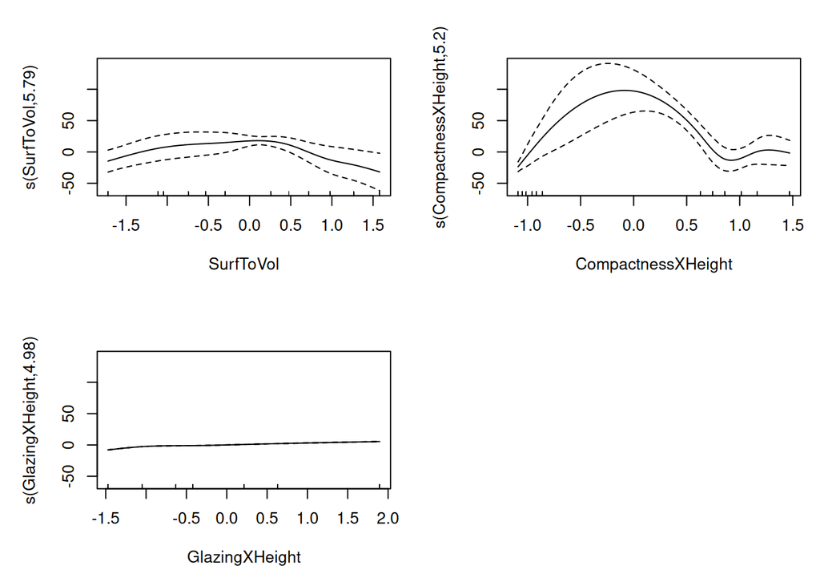

```r
plot(gam_y1, pages = 1, shade = TRUE, shade.col = "lightblue")
```

```r
# Save gam.check diagnostics
png(file.path(img_dir, "gam_y1_diagnostics.png"), width = 1200, height = 900, res = 150)
gam.check(gam_y1)
```

```
##
## Method: REML   Optimizer: outer newton
## full convergence after 12 iterations.
## Gradient range [-2.014737e-07,2.616684e-07]
## (score 660.7737 & scale 0.4029965).
## Hessian positive definite, eigenvalue range [1.906743,304.5466].
## Model rank =  25 / 25
##
## Basis dimension (k) checking results. Low p-value (k-index<1) may
## indicate that k is too low, especially if edf is close to k'.
##
##                         k'  edf k-index p-value
## s(SurfToVol)          9.00 5.79    0.56  <2e-16 ***
## s(CompactnessXHeight) 7.00 5.20    0.55  <2e-16 ***
## s(GlazingXHeight)     5.00 4.98    0.56  <2e-16 ***
## ---
## Signif. codes:  0 '***' 0.001 '**' 0.01 '*' 0.05 '.' 0.1 ' ' 1
```

```r
dev.off()
```

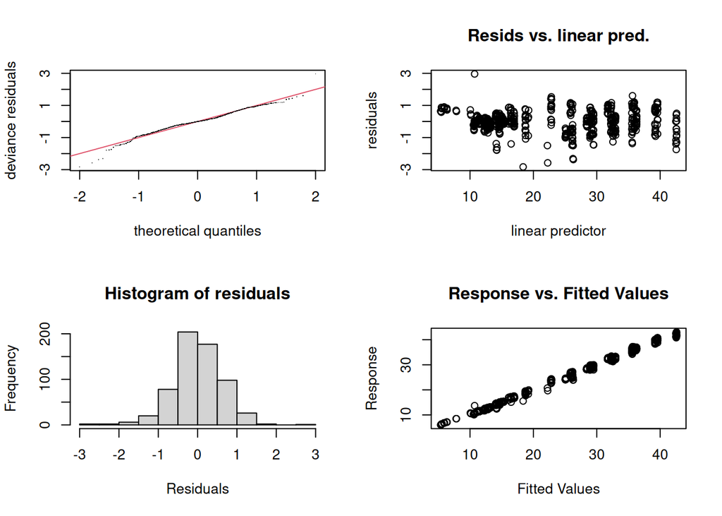

```
##
## Method: REML   Optimizer: outer newton
## full convergence after 12 iterations.
## Gradient range [-2.014737e-07,2.616684e-07]
## (score 660.7737 & scale 0.4029965).
## Hessian positive definite, eigenvalue range [1.906743,304.5466].
## Model rank =  25 / 25
##
## Basis dimension (k) checking results. Low p-value (k-index<1) may
## indicate that k is too low, especially if edf is close to k'.
##
##                         k'  edf k-index p-value
## s(SurfToVol)          9.00 5.79    0.56  <2e-16 ***
## s(CompactnessXHeight) 7.00 5.20    0.55  <2e-16 ***
## s(GlazingXHeight)     5.00 4.98    0.56  <2e-16 ***
## ---
## Signif. codes:  0 '***' 0.001 '**' 0.01 '*' 0.05 '.' 0.1 ' ' 1
```

```r
gam.check(gam_y1)
```

```r
pred_gam_y1 <- predict(gam_y1, newdata = gam_test)
results_y1  <- rbind(results_y1,
  eval_reg(df_test$HeatingLoad, pred_gam_y1, "GAM")
)
```

```
## GAM                             RMSE=0.6844  MAE=0.4657  R²=0.9955
```

### 10.1.2 Model 8 — MARS

Multivariate Adaptive Regression Splines builds a piecewise linear model by automatically detecting breakpoints, called knots, in the predictor space and fitting separate linear segments on either side. It also considers interaction terms up to degree two, meaning it can capture cases where the effect of one predictor depends on the value of another. The result is a model that is more flexible than ordinary linear regression but still produces an explicit equation that can be inspected and interpreted. Variable importance scores from the evimp function show which predictors contribute most to the fit.

```r
# ============================================================
# 8.8  MODEL 8 — MARS: Multivariate Adaptive Regression Splines (Non-linear)
# ============================================================

# Full feature set — original plus engineered, excluding aliased columns
mars_features <- c(
  "RelCompactness", "WallArea", "RoofArea",
  "OverallHeight", "Orientation", "GlazingArea", "GlazingAreaDist",
  "CompactnessXHeight", "WallToRoofRatio", "GlazingXCompactness",
  "SurfToVol", "GlazingXHeight", "WallXGlazing",
  "CompactnessSquared", "GlazingToWall", "EnvelopeArea", "WallPerHeight"
)

mars_y1 <- earth(
  HeatingLoad ~ .,
  data   = df_train[, c(mars_features, "HeatingLoad")],
  degree = 2
)

summary(mars_y1)
```

```
## Call: earth(formula=HeatingLoad~.,
##             data=df_train[,c(mars_features,"HeatingLoad")], degree=2)
##
##                                                           coefficients
## (Intercept)                                                   7.258543
## h(RelCompactness- -0.234718)                                 18.767767
## h(0.583477-WallToRoofRatio)                                   4.551716
## h(WallToRoofRatio-0.583477)                                  -0.960743
## h(-0.629166-GlazingXHeight)                                  -2.905066
## h(GlazingXHeight- -0.629166)                                  2.645372
## h(-0.234718-RelCompactness) * h(EnvelopeArea-1.33127)        -7.975941
## h(-0.234718-RelCompactness) * h(1.33127-EnvelopeArea)        -1.766930
## h(RelCompactness- -0.234718) * h(EnvelopeArea- -0.554472)    87.204028
## h(RelCompactness- -0.234718) * h(-0.554472-EnvelopeArea)     -9.155830
## h(0.0240203-WallArea) * h(0.583477-WallToRoofRatio)          -1.198375
## h(WallArea-0.0240203) * h(0.583477-WallToRoofRatio)           5.806919
## h(-0.629166-GlazingXHeight) * h(-1.09143-WallXGlazing)       -7.693582
##
## Selected 13 of 15 terms, and 6 of 17 predictors
## Termination condition: RSq changed by less than 0.001 at 15 terms
## Importance: GlazingXHeight, RelCompactness, EnvelopeArea, WallToRoofRatio, ...
## Number of terms at each degree of interaction: 1 5 7
## GCV 0.4535948    RSS 251.9991    GRSq 0.9955315    RSq 0.9959568
```

```r
# Save plotmo response curves
png(file.path(img_dir, "mars_y1_response_curves.png"), width = 1400, height = 1000, res = 150)
plotmo(mars_y1, main = "MARS Response Curves — Heating Load (Y1)")
```

```
##  plotmo grid:    RelCompactness   WallArea  RoofArea OverallHeight Orientation
##                      -0.1390924 0.02402032 0.1536008             0  -0.4325858
##  GlazingArea GlazingAreaDist CompactnessXHeight WallToRoofRatio
##    0.1249474      0.09626662         -0.1148532      -0.1730589
##  GlazingXCompactness   SurfToVol GlazingXHeight WallXGlazing CompactnessSquared
##          -0.01258211 -0.01941341     -0.4187606  -0.01034529          -0.198309
##  GlazingToWall EnvelopeArea WallPerHeight
##     0.07833419  -0.08303689   -0.08226108
```

```r
dev.off()
```

```
##  plotmo grid:    RelCompactness   WallArea  RoofArea OverallHeight Orientation
##                      -0.1390924 0.02402032 0.1536008             0  -0.4325858
##  GlazingArea GlazingAreaDist CompactnessXHeight WallToRoofRatio
##    0.1249474      0.09626662         -0.1148532      -0.1730589
##  GlazingXCompactness   SurfToVol GlazingXHeight WallXGlazing CompactnessSquared
##          -0.01258211 -0.01941341     -0.4187606  -0.01034529          -0.198309
##  GlazingToWall EnvelopeArea WallPerHeight
##     0.07833419  -0.08303689   -0.08226108
```

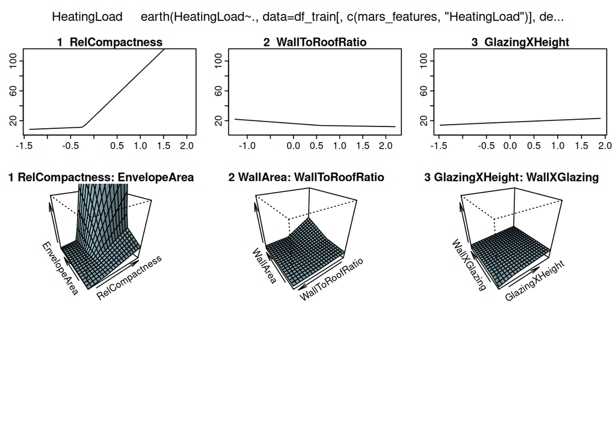

```r
plotmo(mars_y1)
```

```r
# Save variable importance (evimp)
mars_y1_imp <- evimp(mars_y1)
print(mars_y1_imp)
```

```
##                 nsubsets   gcv    rss
## GlazingXHeight        10  42.6   42.4
## RelCompactness        10  36.5   36.3
## EnvelopeArea          10  36.5   36.3
## WallToRoofRatio        9 100.0> 100.0>
## WallXGlazing           8  20.9   20.6
## WallArea               7  14.0   13.8
```

[figure not shown]

```r
# evimp() returns a matrix whose column count can vary by earth version.
# Use column index 1 (nsubsets) rather than names to stay version-safe.
mars_imp_df <- data.frame(
  Feature  = rownames(mars_y1_imp),
  nsubsets = mars_y1_imp[, 1],
  stringsAsFactors = FALSE
) %>%
  arrange(desc(nsubsets))

p_mars_y1_imp <- ggplot(mars_imp_df, aes(x = reorder(Feature, nsubsets), y = nsubsets)) +
  geom_col(fill = "steelblue", alpha = 0.8) +
  geom_text(aes(label = nsubsets), hjust = -0.2, size = 3) +
  coord_flip() +
  labs(title = "MARS Variable Importance — Heating Load (Y1)",
       x = "Feature", y = "Number of Model Subsets") +
  theme_minimal()
ggsave(file.path(img_dir, "mars_y1_variable_importance.png"),
       plot = p_mars_y1_imp, width = 10, height = 7, dpi = 150)
print(p_mars_y1_imp)
```

```r
pred_mars_y1 <- predict(mars_y1, newdata = df_test)
results_y1   <- rbind(results_y1,
  eval_reg(df_test$HeatingLoad, pred_mars_y1, "MARS")
)
```

```
## MARS                            RMSE=0.7109  MAE=0.4769  R²=0.9951
```

### 10.1.3 Model 9 — Regression Tree

A single regression tree partitions the feature space into rectangular regions by repeatedly splitting on the predictor that most reduces prediction error. The result is a model that is visually intuitive and makes no assumptions about functional form, but which can be unstable since small changes in the training data can produce quite different tree structures. A complexity parameter of 0.01 is set as the minimum split improvement threshold, and the tree is then pruned back to the depth that minimises cross-validated error, trading some training accuracy for better generalisation.

```r
# ============================================================
# 8.9  MODEL 9 — Regression Tree (Non-parametric)
# ============================================================
features <- c(
  "RelCompactness", "WallArea", "RoofArea",
  "OverallHeight", "Orientation", "GlazingArea", "GlazingAreaDist",
  "CompactnessXHeight", "WallToRoofRatio", "GlazingXCompactness",
  "SurfToVol", "GlazingXHeight", "WallXGlazing",
  "CompactnessSquared", "GlazingToWall", "EnvelopeArea", "WallPerHeight"
)

tree_y1 <- rpart(HeatingLoad ~ .,
                 data    = df_train[, c(features, "HeatingLoad")],
                 control = rpart.control(cp = 0.01))

# Save full tree plot
png(file.path(img_dir, "tree_y1_full.png"), width = 1400, height = 900, res = 150)
rpart.plot(tree_y1, main = "Regression Tree — Heating Load", roundint = FALSE)
dev.off()
```

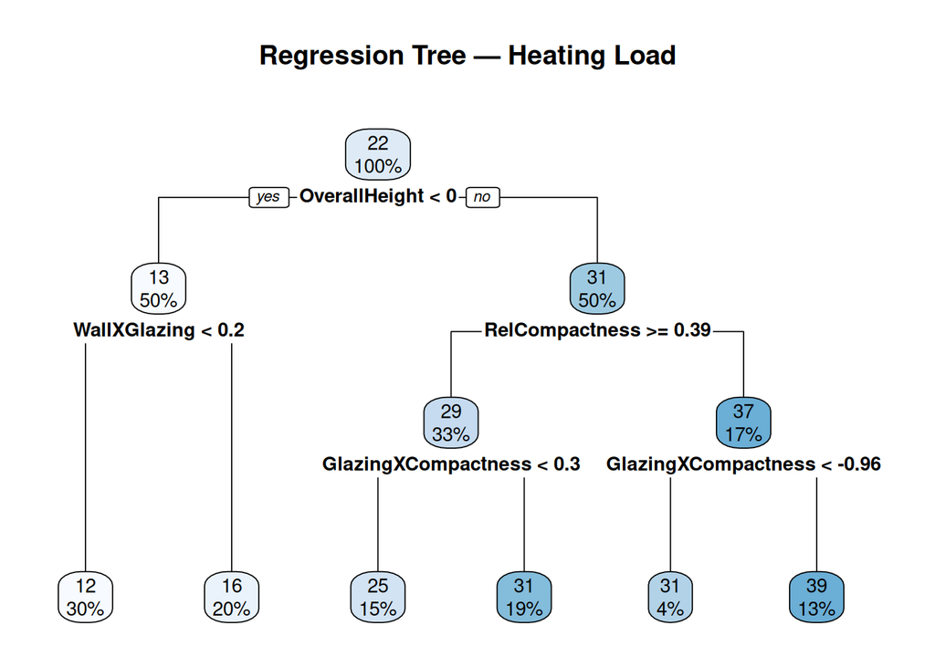

```r
rpart.plot(tree_y1, main = "Regression Tree — Heating Load", roundint = FALSE)
```

```r
printcp(tree_y1)
```

```
##
## Regression tree:
## rpart(formula = HeatingLoad ~ ., data = df_train[, c(features,
##     "HeatingLoad")], control = rpart.control(cp = 0.01))
##
## Variables actually used in tree construction:
## [1] GlazingXCompactness OverallHeight       RelCompactness
## [4] WallXGlazing
##
## Root node error: 62327/616 = 101.18
##
## n= 616
##
##         CP nsplit rel error   xerror      xstd
## 1 0.803432      0  1.000000 1.004832 0.0349141
## 2 0.075600      1  0.196568 0.198579 0.0130982
## 3 0.033219      2  0.120967 0.127949 0.0088448
## 4 0.019025      3  0.087749 0.090758 0.0068747
## 5 0.017402      4  0.068724 0.079622 0.0061036
## 6 0.010000      5  0.051322 0.056972 0.0038267
```

```r
optimal_cp <- tree_y1$cptable[which.min(tree_y1$cptable[, "xerror"]), "CP"]
tree_y1_pruned <- prune(tree_y1, cp = optimal_cp)

# Save pruned tree plot
png(file.path(img_dir, "tree_y1_pruned.png"), width = 1400, height = 900, res = 150)
rpart.plot(tree_y1_pruned, main = "Pruned Regression Tree — Heating Load", roundint = FALSE)
dev.off()
```

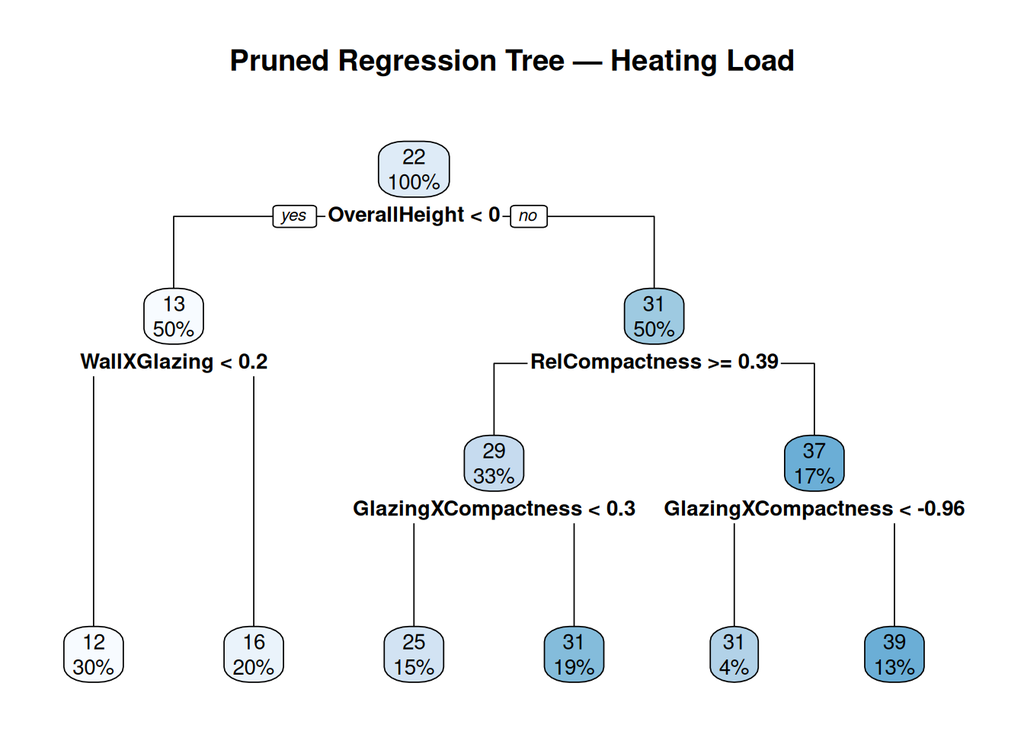

```r
rpart.plot(tree_y1_pruned, main = "Pruned Regression Tree — Heating Load", roundint = FALSE)
```

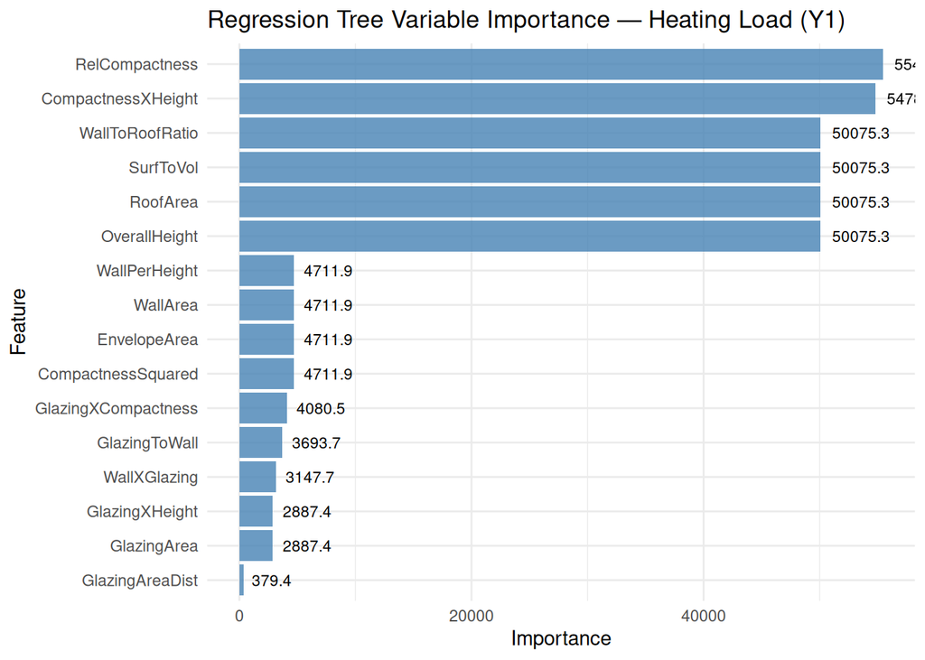

```r
# Variable importance from rpart
tree_y1_imp <- tree_y1_pruned$variable.importance
if (!is.null(tree_y1_imp) && length(tree_y1_imp) > 0) {
  tree_imp_df <- data.frame(
    Feature    = names(tree_y1_imp),
    Importance = as.numeric(tree_y1_imp)
  ) %>% arrange(desc(Importance))

  p_tree_y1_imp <- ggplot(tree_imp_df, aes(x = reorder(Feature, Importance), y = Importance)) +
    geom_col(fill = "steelblue", alpha = 0.8) +
    geom_text(aes(label = round(Importance, 1)), hjust = -0.2, size = 3) +
    coord_flip() +
    labs(title = "Regression Tree Variable Importance — Heating Load (Y1)",
         x = "Feature", y = "Importance") +
    theme_minimal()
  ggsave(file.path(img_dir, "tree_y1_variable_importance.png"),
         plot = p_tree_y1_imp, width = 10, height = 7, dpi = 150)
  print(p_tree_y1_imp)
}
```

```r
pred_tree_y1 <- predict(tree_y1_pruned, newdata = df_test)
results_y1 <- rbind(results_y1,
  eval_reg(df_test$HeatingLoad, pred_tree_y1, "Regression Tree"))
```

```
## Regression Tree                 RMSE=2.5266  MAE=1.8930  R²=0.9384
```

### 10.1.4 Model 10 — Random Forest

Random Forest addresses the instability of single trees by growing a large number of them, each trained on a bootstrap sample of the training data and using a random subset of predictors at each split. Predictions are averaged across all 500 trees, which dramatically reduces variance compared to a single tree. The mtry parameter is set to 3, meaning three randomly selected features are considered at each split. Variable importance plots are produced using both mean decrease in accuracy and mean decrease in node impurity to give a rounded picture of which predictors matter most.

```r
# ============================================================
# 8.10  MODEL 10 — Random Forest (Non-parametric, Ensemble)
# ============================================================
features <- c(
  "RelCompactness", "WallArea", "RoofArea",
  "OverallHeight", "Orientation", "GlazingArea", "GlazingAreaDist",
  "CompactnessXHeight", "WallToRoofRatio", "GlazingXCompactness",
  "SurfToVol", "GlazingXHeight", "WallXGlazing",
  "CompactnessSquared", "GlazingToWall", "EnvelopeArea", "WallPerHeight"
)

set.seed(42)
rf_y1 <- randomForest(HeatingLoad ~ .,
                      data      = df_train[, c(features, "HeatingLoad")],
                      ntree     = 500,
                      mtry      = 3,
                      importance = TRUE)
print(rf_y1)
```

```
##
## Call:
##  randomForest(formula = HeatingLoad ~ ., data = df_train[, c(features,      "HeatingLoad")], ntree = 500, mtry = 3, importance = TRUE)
##                Type of random forest: regression
##                      Number of trees: 500
## No. of variables tried at each split: 3
##
##           Mean of squared residuals: 0.3564218
##                     % Var explained: 99.65
```

```r
# Save variable importance plot
png(file.path(img_dir, "rf_y1_variable_importance.png"), width = 1200, height = 900, res = 150)
varImpPlot(rf_y1, main = "Random Forest Variable Importance — Heating Load (Y1)")
dev.off()
```

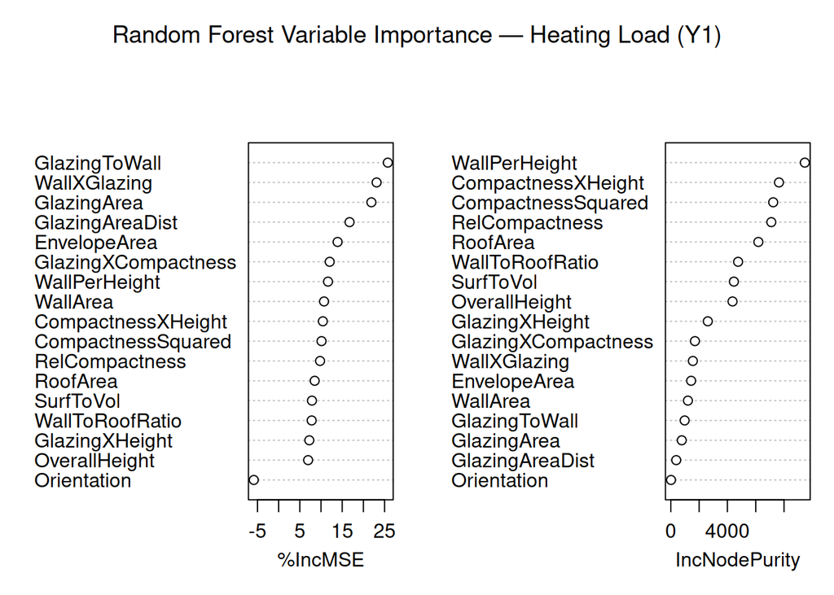

```r
varImpPlot(rf_y1, main = "Random Forest Variable Importance — Heating Load (Y1)")
```

```r
importance(rf_y1)
```

```
##                       %IncMSE IncNodePurity
## RelCompactness       9.772179    7100.65792
## WallArea            10.712793    1208.45321
## RoofArea             8.503580    6187.21138
## OverallHeight        6.955153    4361.07908
## Orientation         -5.865522      14.55855
## GlazingArea         21.890470     773.54635
## GlazingAreaDist     16.737056     381.51317
## CompactnessXHeight  10.430086    7643.68017
## WallToRoofRatio      7.793711    4755.79943
## GlazingXCompactness 12.046347    1703.77092
## SurfToVol            7.854664    4456.93080
## GlazingXHeight       7.235717    2613.34363
## WallXGlazing        23.121929    1557.02157
## CompactnessSquared  10.122440    7234.66899
## GlazingToWall       25.766277     977.91860
## EnvelopeArea        13.911437    1435.09224
## WallPerHeight       11.648031    9468.32828
```

```r
pred_rf_y1 <- predict(rf_y1, newdata = df_test)
results_y1 <- rbind(results_y1,
  eval_reg(df_test$HeatingLoad, pred_rf_y1, "Random Forest"))
```

```
## Random Forest                   RMSE=0.5901  MAE=0.3798  R²=0.9966
```

### 10.1.5 Model 11 — XGBoost

XGBoost is a gradient boosting algorithm that builds trees sequentially, with each new tree correcting the errors made by the ensemble so far. It tends to be among the strongest performers on tabular data because it combines boosting with regularisation terms and subsampling of both rows and columns, which helps prevent overfitting. Early stopping is used here to halt training once the test set error stops improving, avoiding unnecessary rounds. Feature importance scores are extracted after training to identify the most influential predictors.

```r
# ============================================================
# 8.11  MODEL 11 — XGBoost (Non-parametric, Gradient Boosting)
# ============================================================
# Build numeric matrices from the current split (df_train/df_test have factor
# columns after GAM conversion, so model.matrix handles dummy-encoding here).
features <- c(
  "RelCompactness", "WallArea", "RoofArea",
  "OverallHeight", "Orientation", "GlazingArea", "GlazingAreaDist",
  "CompactnessXHeight", "WallToRoofRatio", "GlazingXCompactness",
  "SurfToVol", "GlazingXHeight", "WallXGlazing",
  "CompactnessSquared", "GlazingToWall", "EnvelopeArea", "WallPerHeight"
)

x_train <- model.matrix(HeatingLoad ~ .,
              data = df_train[, c(features, "HeatingLoad")])[, -1]
y_train  <- df_train$HeatingLoad
x_test   <- model.matrix(HeatingLoad ~ .,
              data = df_test[, c(features, "HeatingLoad")])[, -1]

dtrain_y1 <- xgb.DMatrix(data = x_train, label = y_train)
dtest_y1  <- xgb.DMatrix(data = x_test,  label = df_test$HeatingLoad)

params_y1 <- list(
  objective        = "reg:squarederror",
  eta              = 0.1,
  max_depth        = 6,
  subsample        = 0.8,
  colsample_bytree = 0.8
)

xgb_y1 <- xgb.train(
  params               = params_y1,
  data                 = dtrain_y1,
  nrounds              = 200,
  watchlist            = list(train = dtrain_y1, test = dtest_y1),
  verbose              = 0,
  early_stopping_rounds = 20
)
xgb_imp_y1 <- xgb.importance(model = xgb_y1)

# Save XGBoost feature importance plot
png(file.path(img_dir, "xgb_y1_feature_importance.png"), width = 1200, height = 900, res = 150)
xgb.plot.importance(xgb_imp_y1, top_n = 8, main = "XGBoost Feature Importance — Heating Load (Y1)")
dev.off()
```

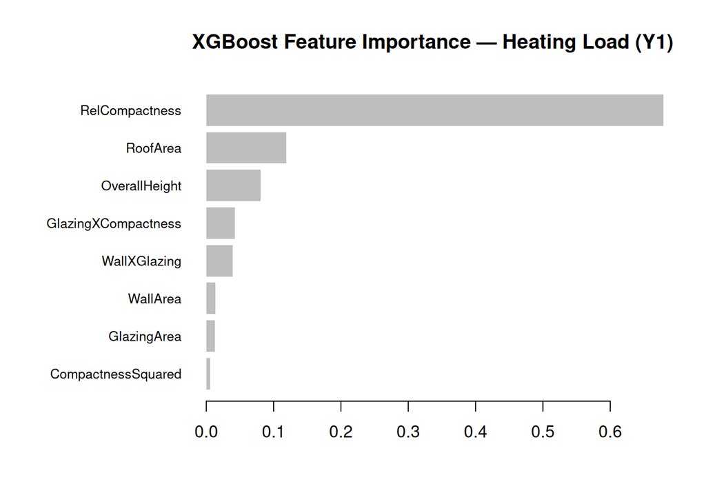

```r
xgb.plot.importance(xgb_imp_y1, top_n = 8, main = "XGBoost Feature Importance — Heating Load (Y1)")
```

```r
pred_xgb_y1 <- predict(xgb_y1, newdata = dtest_y1)
results_y1 <- rbind(results_y1,
  eval_reg(df_test$HeatingLoad, pred_xgb_y1, "XGBoost"))
```

```
## XGBoost                         RMSE=0.2871  MAE=0.2092  R²=0.9992
```

### 10.1.6 Model 12 — SVM Regression

Support Vector Machine regression finds a function that fits as many training points as possible within a tolerance band of width epsilon around the predicted values, while penalising points that fall outside that band. The radial basis function kernel is used here, which maps the data into a higher-dimensional space and allows the model to capture complex nonlinear patterns. The cost parameter of 10 controls how severely outlying points are penalised, and the epsilon value of 0.1 defines the width of the insensitive tube.

```r
# ============================================================
# 8.12  MODEL 12 — SVM Regression (Non-parametric, Kernel)
# ============================================================
library(e1071)
```

```r
features <- c(
  "RelCompactness", "WallArea", "RoofArea",
  "OverallHeight", "Orientation", "GlazingArea", "GlazingAreaDist",
  "CompactnessXHeight", "WallToRoofRatio", "GlazingXCompactness",
  "SurfToVol", "GlazingXHeight", "WallXGlazing",
  "CompactnessSquared", "GlazingToWall", "EnvelopeArea", "WallPerHeight"
)

svm_y1 <- svm(HeatingLoad ~ .,
              data    = df_train[, c(features, "HeatingLoad")],
              type    = "eps-regression",
              kernel  = "radial",
              cost    = 10,
              epsilon = 0.1)
summary(svm_y1)
```

```
##
## Call:
## svm(formula = HeatingLoad ~ ., data = df_train[, c(features, "HeatingLoad")],
##     type = "eps-regression", kernel = "radial", cost = 10, epsilon = 0.1)
##
##
## Parameters:
##    SVM-Type:  eps-regression
##  SVM-Kernel:  radial
##        cost:  10
##       gamma:  0.05882353
##     epsilon:  0.1
##
##
## Number of Support Vectors:  234
```

```r
pred_svm_y1 <- predict(svm_y1, newdata = df_test)
results_y1 <- rbind(results_y1,
  eval_reg(df_test$HeatingLoad, pred_svm_y1, "SVM (RBF)"))
```

```
## SVM (RBF)                       RMSE=1.1068  MAE=0.9673  R²=0.9882
```

### 10.1.7 Model 13 — Neural Network

A single hidden layer neural network is fitted with ten neurons in the hidden layer and a linear output activation, which is appropriate for regression tasks. The features are standardised before training since neural networks are sensitive to the scale of their inputs. Weight decay regularisation is applied with a value of 0.01 to discourage the model from overfitting by penalising large weights. The network is trained for up to 500 iterations.

```r
# ============================================================
# 8.13  MODEL 13 — Neural Network Regression (Non-linear)
# ============================================================
features <- c(
  "RelCompactness", "WallArea", "RoofArea",
  "OverallHeight", "Orientation", "GlazingArea", "GlazingAreaDist",
  "CompactnessXHeight", "WallToRoofRatio", "GlazingXCompactness",
  "SurfToVol", "GlazingXHeight", "WallXGlazing",
  "CompactnessSquared", "GlazingToWall", "EnvelopeArea", "WallPerHeight"
)

preproc <- preProcess(df_train[, features], method = c("center", "scale"))
train_scaled <- predict(preproc, df_train[, features])
test_scaled  <- predict(preproc, df_test[, features])
train_scaled$HeatingLoad <- df_train$HeatingLoad

set.seed(42)
nn_y1 <- nnet(HeatingLoad ~ ., data = train_scaled,
              size   = 10,
              linout = TRUE,
              maxit  = 500,
              decay  = 0.01,
              trace  = FALSE)

pred_nn_y1 <- predict(nn_y1, newdata = test_scaled)
results_y1 <- rbind(results_y1,
  eval_reg(df_test$HeatingLoad, pred_nn_y1, "Neural Network"))
```

```
## Neural Network                  RMSE=0.4077  MAE=0.3069  R²=0.9984
```

### 10.1.8 Model 14 — k-Nearest Neighbors

k-Nearest Neighbors regression predicts the heating load for a new observation by finding the k most similar buildings in the training set and averaging their observed heating loads. It makes no assumptions at all about the functional form of the relationship and adapts entirely to local patterns in the data. The value of k is selected through 10-fold cross-validation across a grid of candidate values ranging from 3 to 15. Smaller values of k produce more flexible but noisier predictions, while larger values produce smoother but potentially biased ones.

```r
# ============================================================
# 8.14  MODEL 14 — k-Nearest Neighbors Regression (Non-parametric)
# ============================================================
features <- c(
  "RelCompactness", "WallArea", "RoofArea",
  "OverallHeight", "Orientation", "GlazingArea", "GlazingAreaDist",
  "CompactnessXHeight", "WallToRoofRatio", "GlazingXCompactness",
  "SurfToVol", "GlazingXHeight", "WallXGlazing",
  "CompactnessSquared", "GlazingToWall", "EnvelopeArea", "WallPerHeight"
)

set.seed(42)
knn_ctrl <- trainControl(method = "cv", number = 10)
knn_y1 <- train(HeatingLoad ~ .,
                data      = df_train[, c(features, "HeatingLoad")],
                method    = "knn",
                preProcess = c("center", "scale"),
                trControl  = knn_ctrl,
                tuneGrid   = data.frame(k = c(3, 5, 7, 9, 11, 15)))
print(knn_y1)
```

```
## k-Nearest Neighbors
##
## 616 samples
##  17 predictor
##
## Pre-processing: centered (17), scaled (17)
## Resampling: Cross-Validated (10 fold)
## Summary of sample sizes: 554, 554, 555, 555, 554, 555, ...
## Resampling results across tuning parameters:
##
##   k   RMSE      Rsquared   MAE
##    3  1.518778  0.9775257  0.8821136
##    5  1.758662  0.9702591  1.0962967
##    7  2.135073  0.9565743  1.3588568
##    9  2.460554  0.9420752  1.6091073
##   11  2.601774  0.9350792  1.7374966
##   15  2.764543  0.9259896  1.8796234
##
## RMSE was used to select the optimal model using the smallest value.
## The final value used for the model was k = 3.
```

```r
# Save k-NN tuning curve
p_knn_y1 <- plot(knn_y1)
png(file.path(img_dir, "knn_y1_tuning_curve.png"), width = 900, height = 700, res = 150)
print(plot(knn_y1, main = "k-NN CV Tuning — Heating Load (Y1)"))
dev.off()
```

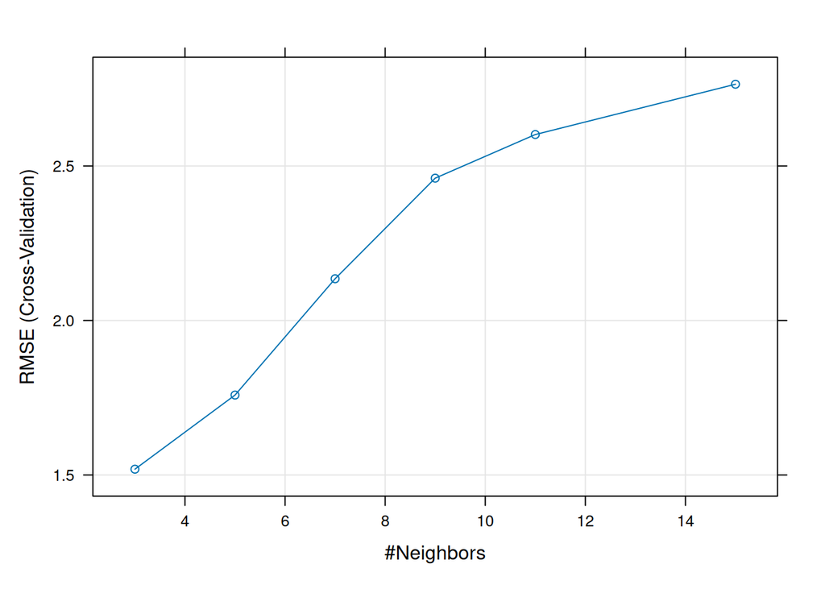

```r
plot(knn_y1)
```

```r
pred_knn_y1 <- predict(knn_y1, newdata = df_test)
results_y1 <- rbind(results_y1,
  eval_reg(df_test$HeatingLoad, pred_knn_y1, "k-NN Regression"))
```

```
## k-NN Regression                 RMSE=1.4160  MAE=0.7718  R²=0.9807
```

### 10.1.9 Y1 — Model Comparison

All eight nonlinear and semi-parametric models are now ranked by test set RMSE. The spread of results across these models tends to be wider than for the parametric models, reflecting the greater variability in how well different flexible approaches suit a given dataset. The R squared comparison chart provides a complementary view of explanatory power.

```r
# ============================================================
# Y1 COMPARISON — Semi-parametric & Nonlinear Models Only
# ============================================================
results_y1 <- results_y1 %>% arrange(RMSE)
cat("\n========== Y1: HEATING LOAD — SEMI-PARAMETRIC & NONLINEAR MODEL COMPARISON ==========\n")
```

```
##
## ========== Y1: HEATING LOAD — SEMI-PARAMETRIC & NONLINEAR MODEL COMPARISON ==========
```

```r
print(results_y1, row.names = FALSE)
```

```
##            Model      RMSE       MAE        R2
##          XGBoost 0.2870864 0.2092046 0.9992053
##   Neural Network 0.4077399 0.3069460 0.9983969
##    Random Forest 0.5900904 0.3797827 0.9966423
##              GAM 0.6843754 0.4657050 0.9954836
##             MARS 0.7109128 0.4769369 0.9951266
##        SVM (RBF) 1.1067743 0.9672514 0.9881881
##  k-NN Regression 1.4160445 0.7718410 0.9806645
##  Regression Tree 2.5266348 1.8930203 0.9384418
```

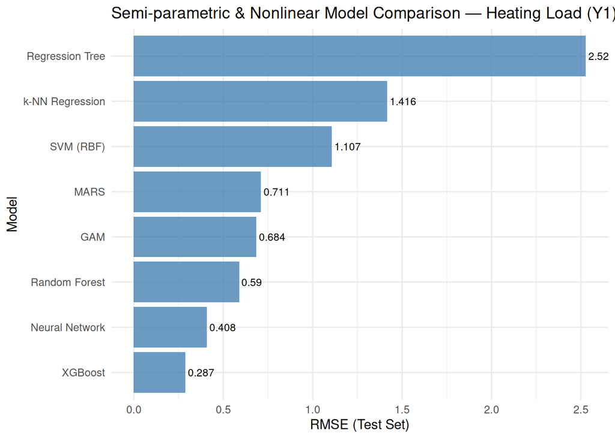

```r
p_rmse_y1 <- ggplot(results_y1, aes(x = reorder(Model, RMSE), y = RMSE)) +
  geom_col(fill = "steelblue", alpha = 0.8) +
  geom_text(aes(label = round(RMSE, 3)), hjust = -0.1, size = 3) +
  coord_flip() +
  labs(title = "Semi-parametric & Nonlinear Model Comparison — Heating Load (Y1)",
       x = "Model", y = "RMSE (Test Set)") +
  theme_minimal()
ggsave(file.path(img_dir, "comparison_y1_rmse.png"),
       plot = p_rmse_y1, width = 10, height = 7, dpi = 150)
print(p_rmse_y1)
```

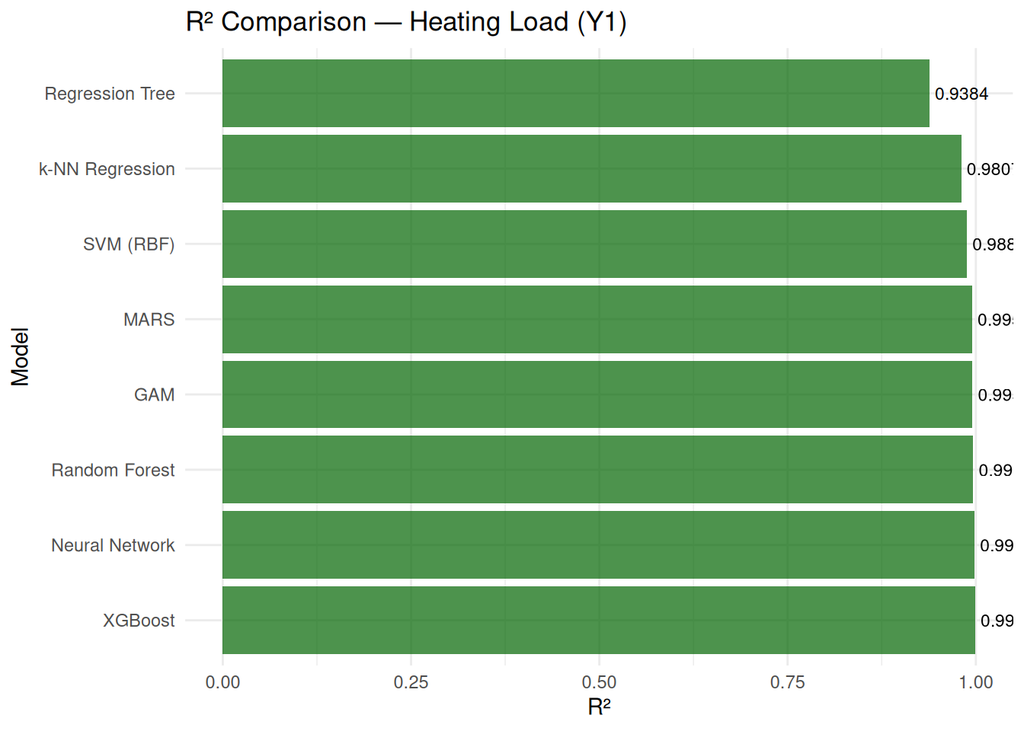

```r
p_r2_y1 <- ggplot(results_y1, aes(x = reorder(Model, -R2), y = R2)) +
  geom_col(fill = "darkgreen", alpha = 0.7) +
  geom_text(aes(label = round(R2, 4)), hjust = -0.1, size = 3) +
  coord_flip() +
  labs(title = "R² Comparison — Heating Load (Y1)",
       x = "Model", y = "R²") +
  theme_minimal()
ggsave(file.path(img_dir, "comparison_y1_r2.png"),
       plot = p_r2_y1, width = 10, height = 7, dpi = 150)
print(p_r2_y1)
```

## 10.2 Y2 — Cooling Load

```r
results_y2 <- data.frame()
```

### 10.2.1 Elastic Net — Cooling Load (Y2)

```r
# ============================================================
# MODEL X — Elastic Net: CoolingLoad (Y2)
# ============================================================
library(car)
elastic_features_y2 <- c(
  "CompactnessSquared",
  "WallToRoofRatio",
  "GlazingXHeight",
  "Orientation"
)

X_train_en <- as.matrix(df_train[, elastic_features_y2])
X_test_en  <- as.matrix(df_test[,  elastic_features_y2])
y_train_y2 <- df_train$CoolingLoad
y_test_y2  <- df_test$CoolingLoad

set.seed(42)
cv_fit_y2 <- cv.glmnet(
  X_train_en, y_train_y2,
  alpha  = 0.5,
  nfolds = 10
)

png(file.path(img_dir, "elastic_net_y2_cv.png"), width = 900, height = 700, res = 150)
plot(cv_fit_y2, main = "Elastic Net CV — Cooling Load (Y2)")
dev.off()
```

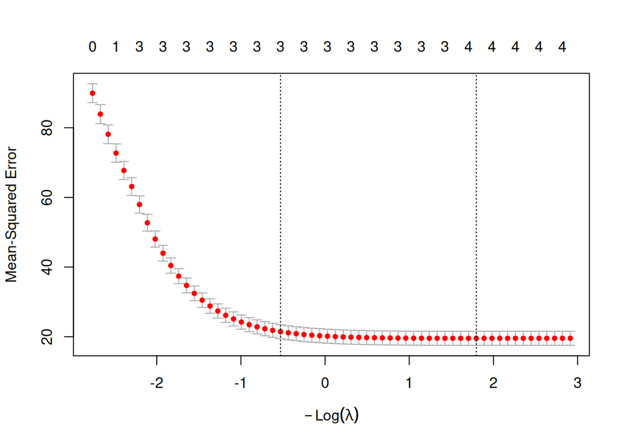

```r
plot(cv_fit_y2)
```

```r
cat("Best lambda (min):", cv_fit_y2$lambda.min, "\n")
```

```
## Best lambda (min): 0.1659604
```

```r
cat("\nModel coefficients:\n")
```

```
##
## Model coefficients:
```

```r
print(coef(cv_fit_y2, s = "lambda.min"))
```

```
## 5 x 1 sparse Matrix of class "dgCMatrix"
##                      lambda.min
## (Intercept)        24.571834416
## CompactnessSquared  1.086859954
## WallToRoofRatio     6.048544560
## GlazingXHeight      2.654608828
## Orientation         0.009286374
```

```r
preds_y2 <- predict(cv_fit_y2, newx = X_test_en, s = "lambda.min")

results_y2 <- rbind(results_y2,
  eval_reg(y_test_y2, as.vector(preds_y2), "Elastic Net"))
```

```
## Elastic Net                     RMSE=4.2179  MAE=3.0769  R²=0.8073
```

```r
cat("\n--- Elastic Net: CoolingLoad Test Performance ---\n")
```

```
##
## --- Elastic Net: CoolingLoad Test Performance ---
```

```r
print(results_y2)
```

```
##         Model    RMSE      MAE        R2
## 1 Elastic Net 4.21791 3.076932 0.8072559
```

### 10.2.2 Model 7 — GAM

The GAM for cooling load uses the same smooth term structure as the heating load model, with REML fitting to control smoothness. The partial effect plots produced by the model are particularly informative here because they show visually how each building characteristic influences cooling demand across its observed range.

```r
# --- 9.7  GAM ---
gam_y2 <- gam(
  CoolingLoad ~
    s(RelCompactness, k = 12) +
    s(WallArea, k = 7) +
    RoofArea + OverallHeight + Orientation +
    GlazingArea + GlazingAreaDist,
  data   = df_train,
  method = "REML"
)
summary(gam_y2)
```

```
##
## Family: gaussian
## Link function: identity
##
## Formula:
## CoolingLoad ~ s(RelCompactness, k = 12) + s(WallArea, k = 7) +
##     RoofArea + OverallHeight + Orientation + GlazingArea + GlazingAreaDist
##
## Parametric coefficients:
##                 Estimate Std. Error t value Pr(>|t|)
## (Intercept)     24.57183    0.07178 342.322   <2e-16 ***
## RoofArea        23.92288   32.89301   0.727   0.4673
## OverallHeight   21.47447   12.06404   1.780   0.0756 .
## Orientation      0.08249    0.07193   1.147   0.2519
## GlazingArea      1.85835    0.07405  25.097   <2e-16 ***
## GlazingAreaDist  0.06967    0.07384   0.943   0.3458
## ---
## Signif. codes:  0 '***' 0.001 '**' 0.01 '*' 0.05 '.' 0.1 ' ' 1
##
## Approximate significance of smooth terms:
##                     edf Ref.df     F p-value
## s(RelCompactness) 5.146  5.172 1.732  0.0977 .
## s(WallArea)       3.811  3.827 1.258  0.2459
## ---
## Signif. codes:  0 '***' 0.001 '**' 0.01 '*' 0.05 '.' 0.1 ' ' 1
##
## R-sq.(adj) =  0.965   Deviance explained = 96.6%
## -REML = 1257.3  Scale est. = 3.1739    n = 616
```

```r
# Save GAM smooth effects
png(file.path(img_dir, "gam_y2_smooth_effects.png"), width = 1200, height = 900, res = 150)
plot(gam_y2, pages = 1, shade = TRUE, shade.col = "lightyellow",
     main = "GAM Smooth Effects — Cooling Load (Y2)")
dev.off()
```

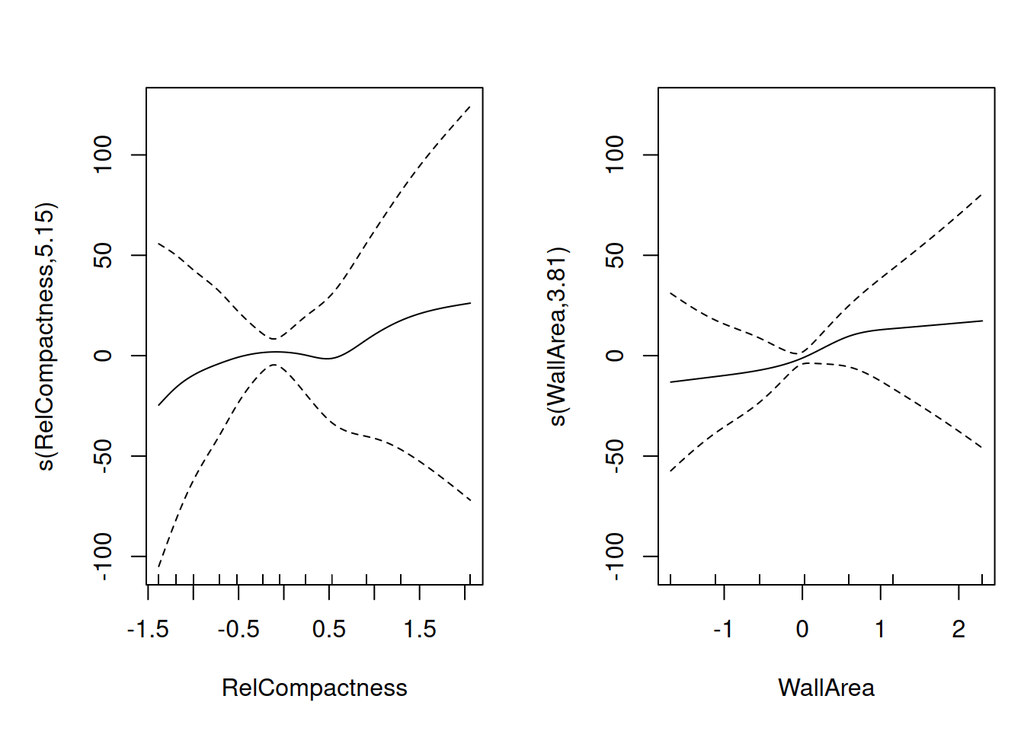

```r
plot(gam_y2, pages = 1, shade = TRUE, shade.col = "lightyellow")
```

```r
# Save GAM diagnostics
png(file.path(img_dir, "gam_y2_diagnostics.png"), width = 1200, height = 900, res = 150)
gam.check(gam_y2)
```

```
##
## Method: REML   Optimizer: outer newton
## full convergence after 9 iterations.
## Gradient range [-0.0002524498,0.0001689398]
## (score 1257.336 & scale 3.173851).
## Hessian positive definite, eigenvalue range [0.9497936,304.021].
## Model rank =  23 / 23
##
## Basis dimension (k) checking results. Low p-value (k-index<1) may
## indicate that k is too low, especially if edf is close to k'.
##
##                      k'   edf k-index p-value
## s(RelCompactness) 11.00  5.15    0.81  <2e-16 ***
## s(WallArea)        6.00  3.81    0.91   0.015 *
## ---
## Signif. codes:  0 '***' 0.001 '**' 0.01 '*' 0.05 '.' 0.1 ' ' 1
```

```r
dev.off()
```

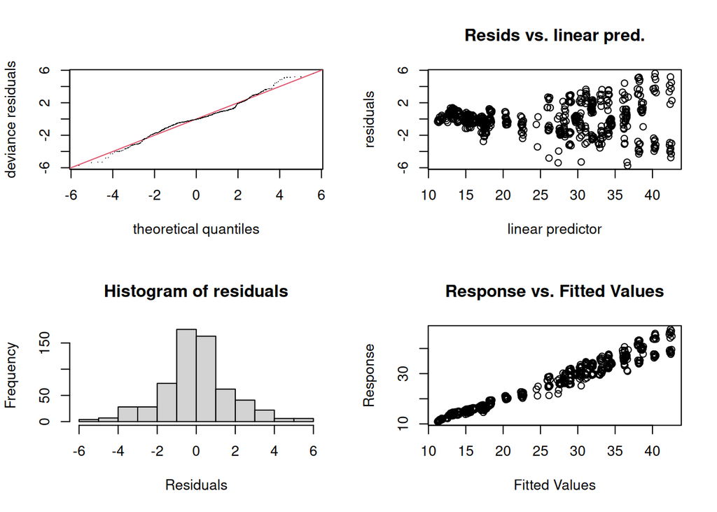

```
##
## Method: REML   Optimizer: outer newton
## full convergence after 9 iterations.
## Gradient range [-0.0002524498,0.0001689398]
## (score 1257.336 & scale 3.173851).
## Hessian positive definite, eigenvalue range [0.9497936,304.021].
## Model rank =  23 / 23
##
## Basis dimension (k) checking results. Low p-value (k-index<1) may
## indicate that k is too low, especially if edf is close to k'.
##
##                      k'   edf k-index p-value
## s(RelCompactness) 11.00  5.15    0.81  <2e-16 ***
## s(WallArea)        6.00  3.81    0.91    0.01 **
## ---
## Signif. codes:  0 '***' 0.001 '**' 0.01 '*' 0.05 '.' 0.1 ' ' 1
```

```r
gam.check(gam_y2)
```

```r
pred_gam_y2 <- predict(gam_y2, newdata = df_test)
results_y2 <- rbind(results_y2,
  eval_reg(df_test$CoolingLoad, pred_gam_y2, "GAM"))
```

```
## GAM                             RMSE=1.8838  MAE=1.3689  R²=0.9616
```

### 10.2.3 Model 8 — MARS

MARS is applied to cooling load with the same degree-two setting to allow pairwise interactions. Comparing the knot locations and retained terms to those from the heating load model gives a sense of whether the same nonlinearities are present in both energy demands or whether the relationships differ in character.

```r
# --- 9.8  MARS ---
mars_y2 <- earth(CoolingLoad ~ .,
                 data   = df_train[, c(features, "CoolingLoad")],
                 degree = 2)
summary(mars_y2)
```

```
## Call: earth(formula=CoolingLoad~., data=df_train[,c(features,"CoolingLoad")],
##             degree=2)
##
##                                                          coefficients
## (Intercept)                                                134.010625
## h(0.630281-CompactnessXHeight)                             -54.135793
## h(CompactnessXHeight-0.630281)                              90.387161
## h(-0.92073-WallXGlazing)                                    -4.266195
## h(WallXGlazing- -0.92073)                                    1.833353
## h(1.42786-WallPerHeight)                                   -62.963415
## h(WallPerHeight-1.42786)                                    12.233360
## h(0.0240203-WallArea) * h(CompactnessXHeight-0.630281)     -42.106601
## h(WallArea-0.0240203) * h(CompactnessXHeight-0.630281)     297.637760
## h(0.630281-CompactnessXHeight) * h(SurfToVol-1.26321)       11.262294
## h(0.630281-CompactnessXHeight) * h(1.26321-SurfToVol)      -18.092388
## h(1.0124-CompactnessXHeight) * h(WallXGlazing- -0.92073)    -0.353839
## h(CompactnessXHeight-1.0124) * h(WallXGlazing- -0.92073)     3.875986
## h(0.986962-WallToRoofRatio) * h(1.42786-WallPerHeight)      14.271771
##
## Selected 14 of 15 terms, and 6 of 17 predictors
## Termination condition: RSq changed by less than 0.001 at 15 terms
## Importance: CompactnessXHeight, WallArea, WallXGlazing, WallPerHeight, ...
## Number of terms at each degree of interaction: 1 6 7
## GCV 2.93605    RSS 1617.241    GRSq 0.9674508    RSq 0.9708
```

```r
# Save MARS response curves
png(file.path(img_dir, "mars_y2_response_curves.png"), width = 1400, height = 1000, res = 150)
plotmo(mars_y2, main = "MARS Response Curves — Cooling Load (Y2)")
```

```
##  plotmo grid:    RelCompactness   WallArea  RoofArea OverallHeight Orientation
##                      -0.1390924 0.02402032 0.1536008             0  -0.4325858
##  GlazingArea GlazingAreaDist CompactnessXHeight WallToRoofRatio
##    0.1249474      0.09626662         -0.1148532      -0.1730589
##  GlazingXCompactness   SurfToVol GlazingXHeight WallXGlazing CompactnessSquared
##          -0.01258211 -0.01941341     -0.4187606  -0.01034529          -0.198309
##  GlazingToWall EnvelopeArea WallPerHeight
##     0.07833419  -0.08303689   -0.08226108
```

```r
dev.off()
```

```
##  plotmo grid:    RelCompactness   WallArea  RoofArea OverallHeight Orientation
##                      -0.1390924 0.02402032 0.1536008             0  -0.4325858
##  GlazingArea GlazingAreaDist CompactnessXHeight WallToRoofRatio
##    0.1249474      0.09626662         -0.1148532      -0.1730589
##  GlazingXCompactness   SurfToVol GlazingXHeight WallXGlazing CompactnessSquared
##          -0.01258211 -0.01941341     -0.4187606  -0.01034529          -0.198309
##  GlazingToWall EnvelopeArea WallPerHeight
##     0.07833419  -0.08303689   -0.08226108
```

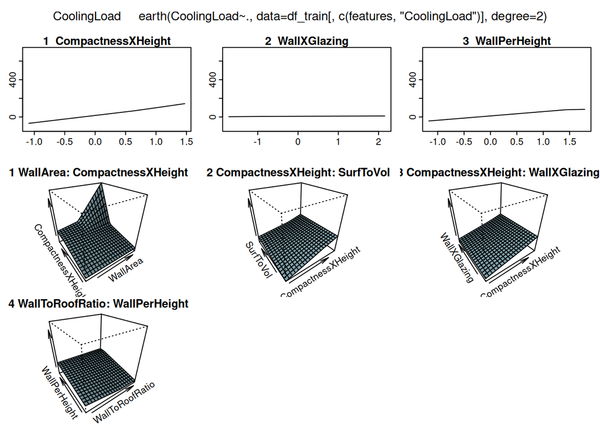

```r
plotmo(mars_y2)
```

```r
# Save MARS variable importance
mars_y2_imp <- evimp(mars_y2)
print(mars_y2_imp)
```

```
##                    nsubsets   gcv    rss
## CompactnessXHeight       13 100.0  100.0
## WallArea                 12  41.6   41.7
## WallXGlazing             11  33.7   33.8
## WallPerHeight            10  25.7   25.9
## SurfToVol                 7  16.9   17.2
## WallToRoofRatio           6  18.2>  18.1>
```

[figure not shown]

```r
# evimp() returns a matrix whose column count can vary by earth version.
# Use column index 1 (nsubsets) rather than names to stay version-safe.
mars_imp_df_y2 <- data.frame(
  Feature  = rownames(mars_y2_imp),
  nsubsets = mars_y2_imp[, 1],
  stringsAsFactors = FALSE
) %>%
  arrange(desc(nsubsets))

p_mars_y2_imp <- ggplot(mars_imp_df_y2, aes(x = reorder(Feature, nsubsets), y = nsubsets)) +
  geom_col(fill = "darkorange", alpha = 0.8) +
  geom_text(aes(label = nsubsets), hjust = -0.2, size = 3) +
  coord_flip() +
  labs(title = "MARS Variable Importance — Cooling Load (Y2)",
       x = "Feature", y = "Number of Model Subsets") +
  theme_minimal()
ggsave(file.path(img_dir, "mars_y2_variable_importance.png"),
       plot = p_mars_y2_imp, width = 10, height = 7, dpi = 150)
print(p_mars_y2_imp)
```

```r
pred_mars_y2 <- predict(mars_y2, newdata = df_test)
results_y2 <- rbind(results_y2,
  eval_reg(df_test$CoolingLoad, pred_mars_y2, "MARS"))
```

```
## MARS                            RMSE=1.6372  MAE=1.1022  R²=0.9710
```

### 10.2.4 Model 9 — Regression Tree

The regression tree for cooling load is grown and pruned using the same procedure as for heating load. Because the tree partitions the feature space based purely on reducing prediction error, the structure of the cooling load tree may differ substantially from the heating load tree if the dominant predictors or their interaction patterns are different.

```r
# --- 9.9  Regression Tree ---
tree_y2 <- rpart(CoolingLoad ~ .,
                 data = df_train[, c(features, "CoolingLoad")])
optimal_cp_y2 <- tree_y2$cptable[which.min(tree_y2$cptable[, "xerror"]), "CP"]
tree_y2_pruned <- prune(tree_y2, cp = optimal_cp_y2)

# Save pruned tree
png(file.path(img_dir, "tree_y2_pruned.png"), width = 1400, height = 900, res = 150)
rpart.plot(tree_y2_pruned, main = "Pruned Regression Tree — Cooling Load (Y2)", roundint = FALSE)
dev.off()
```

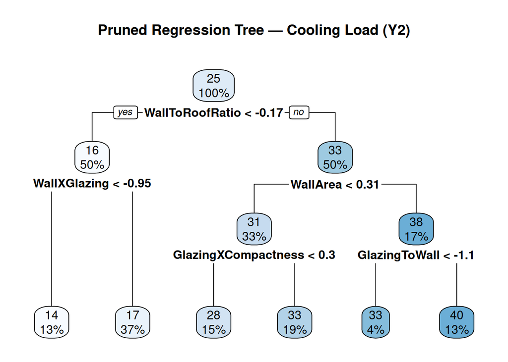

```r
rpart.plot(tree_y2_pruned, main = "Pruned Regression Tree — Cooling Load (Y2)")
```

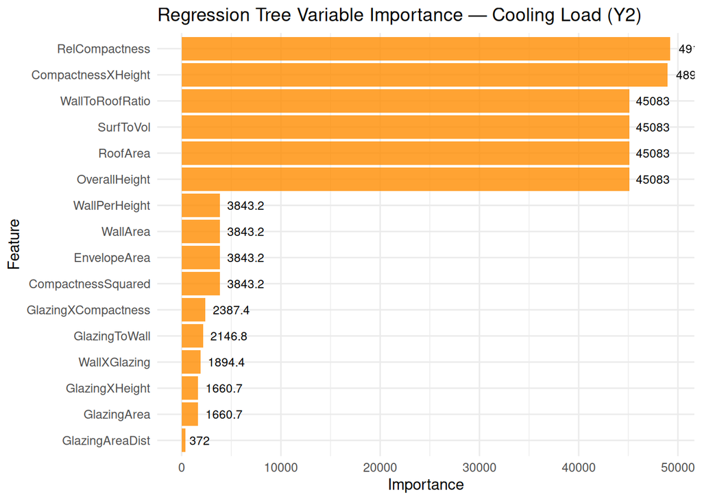

```r
# Variable importance from rpart
tree_y2_imp <- tree_y2_pruned$variable.importance
if (!is.null(tree_y2_imp) && length(tree_y2_imp) > 0) {
  tree_imp_df_y2 <- data.frame(
    Feature    = names(tree_y2_imp),
    Importance = as.numeric(tree_y2_imp)
  ) %>% arrange(desc(Importance))

  p_tree_y2_imp <- ggplot(tree_imp_df_y2,
                          aes(x = reorder(Feature, Importance), y = Importance)) +
    geom_col(fill = "darkorange", alpha = 0.8) +
    geom_text(aes(label = round(Importance, 1)), hjust = -0.2, size = 3) +
    coord_flip() +
    labs(title = "Regression Tree Variable Importance — Cooling Load (Y2)",
         x = "Feature", y = "Importance") +
    theme_minimal()
  ggsave(file.path(img_dir, "tree_y2_variable_importance.png"),
         plot = p_tree_y2_imp, width = 10, height = 7, dpi = 150)
  print(p_tree_y2_imp)
}
```

```r
pred_tree_y2 <- predict(tree_y2_pruned, newdata = df_test)
results_y2 <- rbind(results_y2,
  eval_reg(df_test$CoolingLoad, pred_tree_y2, "Regression Tree"))
```

```
## Regression Tree                 RMSE=2.9305  MAE=2.1995  R²=0.9070
```

### 10.2.5 Model 10 — Random Forest

The Random Forest for cooling load uses the same hyperparameter settings as the heating load forest. Variable importance plots are produced and can be compared to those from the heating load forest to see whether the ranking of predictors is consistent across both targets or whether certain features become more or less relevant depending on which energy demand is being modelled.

```r
# --- 9.10  Random Forest ---
set.seed(42)
rf_y2 <- randomForest(CoolingLoad ~ .,
                      data      = df_train[, c(features, "CoolingLoad")],
                      ntree     = 500,
                      mtry      = 3,
                      importance = TRUE)

# Save RF variable importance plot
png(file.path(img_dir, "rf_y2_variable_importance.png"), width = 1200, height = 900, res = 150)
varImpPlot(rf_y2, main = "Random Forest Variable Importance — Cooling Load (Y2)")
dev.off()
```

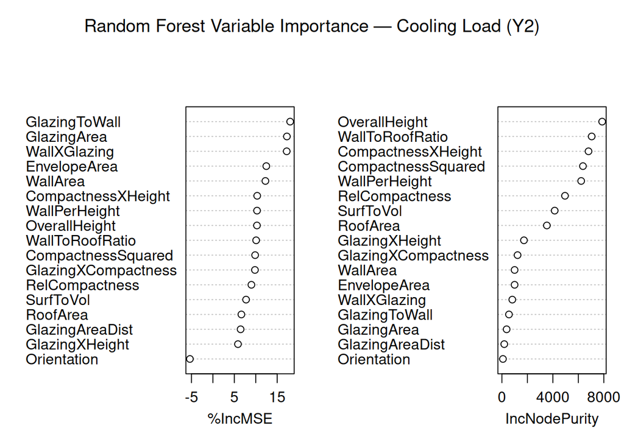

```r
varImpPlot(rf_y2, main = "Random Forest Variable Importance — Cooling Load (Y2)")
```

```r
pred_rf_y2 <- predict(rf_y2, newdata = df_test)
results_y2 <- rbind(results_y2,
  eval_reg(df_test$CoolingLoad, pred_rf_y2, "Random Forest"))
```

```
## Random Forest                   RMSE=1.7695  MAE=1.1112  R²=0.9661
```

### 10.2.6 Model 11 — XGBoost

XGBoost is applied to cooling load by reusing the parameter list defined for heating load, keeping the comparison clean. Early stopping monitors the test set error and halts training when no improvement is seen for 20 consecutive rounds.

```r
# --- 9.11  XGBoost ---
y_train_y2 <- df_train$CoolingLoad
dtrain_y2  <- xgb.DMatrix(data = x_train, label = y_train_y2)
dtest_y2   <- xgb.DMatrix(data = x_test,  label = df_test$CoolingLoad)

xgb_y2 <- xgb.train(
  params               = params_y1,
  data                 = dtrain_y2,
  nrounds              = 200,
  watchlist            = list(train = dtrain_y2, test = dtest_y2),
  verbose              = 0,
  early_stopping_rounds = 20
)
```

```r
xgb_imp_y2 <- xgb.importance(model = xgb_y2)

# Save XGBoost feature importance plot
png(file.path(img_dir, "xgb_y2_feature_importance.png"), width = 1200, height = 900, res = 150)
xgb.plot.importance(xgb_imp_y2, top_n = 8, main = "XGBoost Feature Importance — Cooling Load (Y2)")
dev.off()
```

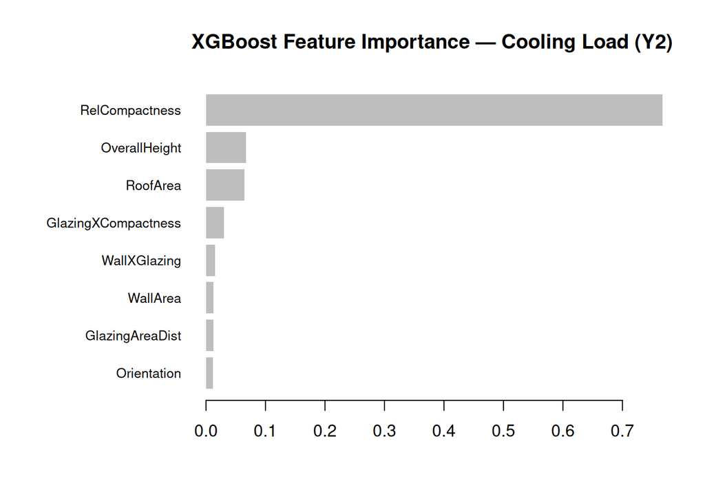

```r
xgb.plot.importance(xgb_imp_y2, top_n = 8, main = "XGBoost Feature Importance — Cooling Load (Y2)")
```

```r
pred_xgb_y2 <- predict(xgb_y2, newdata = dtest_y2)
results_y2 <- rbind(results_y2,
  eval_reg(df_test$CoolingLoad, pred_xgb_y2, "XGBoost"))
```

```
## XGBoost                         RMSE=0.9004  MAE=0.5151  R²=0.9912
```

### 10.2.7 Model 12 — SVM Regression

The radial basis function SVM is fitted to cooling load with the same cost and epsilon values used for heating load. If the error surface for cooling load is smoother or more regular, the SVM may perform relatively better here than it did for heating load.

```r
# --- 9.12  SVM ---
svm_y2 <- svm(CoolingLoad ~ .,
              data    = df_train[, c(features, "CoolingLoad")],
              type    = "eps-regression",
              kernel  = "radial",
              cost    = 10,
              epsilon = 0.1)

pred_svm_y2 <- predict(svm_y2, newdata = df_test)
results_y2 <- rbind(results_y2,
  eval_reg(df_test$CoolingLoad, pred_svm_y2, "SVM (RBF)"))
```

```
## SVM (RBF)                       RMSE=1.9568  MAE=1.3498  R²=0.9585
```

### 10.2.8 Model 13 — Neural Network

The neural network for cooling load is trained on the same scaled features produced during the heating load analysis, with a new column for the cooling load outcome appended to the scaled training data. The architecture and regularisation settings are kept identical to allow a fair comparison of how well the network adapts to each target.

```r
# --- 9.13  Neural Network ---
# Build a clean training frame: start from the scaled features only, then
# append CoolingLoad. This prevents HeatingLoad (added to train_scaled in the
# Y1 NN section) from leaking into the Y2 model as a predictor.
train_scaled_y2 <- train_scaled[, !(names(train_scaled) %in% c("HeatingLoad"))]
train_scaled_y2$CoolingLoad <- df_train$CoolingLoad

set.seed(42)
nn_y2 <- nnet(CoolingLoad ~ ., data = train_scaled_y2,
              size   = 10,
              linout = TRUE,
              maxit  = 500,
              decay  = 0.01,
              trace  = FALSE)

pred_nn_y2 <- predict(nn_y2, newdata = test_scaled)
results_y2 <- rbind(results_y2,
  eval_reg(df_test$CoolingLoad, pred_nn_y2, "Neural Network"))
```

```
## Neural Network                  RMSE=1.2023  MAE=0.8071  R²=0.9843
```

### 10.2.9 Model 14 — k-Nearest Neighbors

k-NN is applied to cooling load using the same cross-validated k selection grid. Because the feature space is identical to the one used for heating load, the optimal k may differ if the local structure of the cooling load surface is smoother or more irregular than that of heating load.

```r
# --- 9.14  k-NN ---
knn_y2 <- train(CoolingLoad ~ .,
                data      = df_train[, c(features, "CoolingLoad")],
                method    = "knn",
                preProcess = c("center", "scale"),
                trControl  = knn_ctrl,
                tuneGrid   = data.frame(k = c(3, 5, 7, 9, 11, 15)))

# Save k-NN tuning curve
png(file.path(img_dir, "knn_y2_tuning_curve.png"), width = 900, height = 700, res = 150)
print(plot(knn_y2, main = "k-NN CV Tuning — Cooling Load (Y2)"))
dev.off()
```

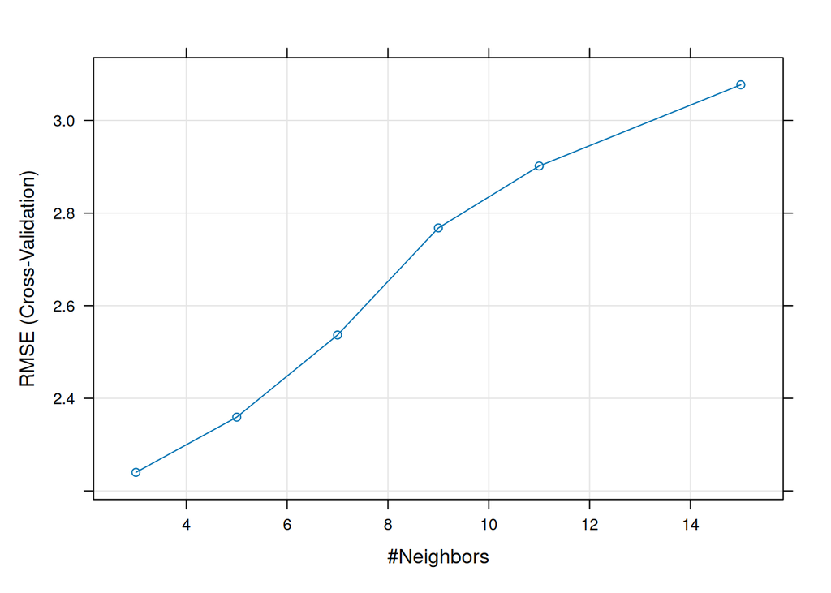

```r
plot(knn_y2)
```

```r
pred_knn_y2 <- predict(knn_y2, newdata = df_test)
results_y2 <- rbind(results_y2,
  eval_reg(df_test$CoolingLoad, pred_knn_y2, "k-NN Regression"))
```

```
## k-NN Regression                 RMSE=2.1982  MAE=1.2947  R²=0.9476
```

### 10.2.10 Y2 — Model Comparison

The final comparison ranks all nonlinear and semi-parametric models for cooling load by test set RMSE. Taken together with the equivalent table for heating load, these results give a clear picture of which flexible approaches generalise best across both energy demands and which are more target-specific in their performance.

```r
# ============================================================
# Y2 COMPARISON — Semi-parametric & Nonlinear Models Only
# ============================================================
results_y2 <- results_y2 %>% arrange(RMSE)
cat("\n========== Y2: COOLING LOAD — SEMI-PARAMETRIC & NONLINEAR MODEL COMPARISON ==========\n")
```

```
##
## ========== Y2: COOLING LOAD — SEMI-PARAMETRIC & NONLINEAR MODEL COMPARISON ==========
```

```r
print(results_y2, row.names = FALSE)
```

```
##            Model      RMSE       MAE        R2
##          XGBoost 0.9003635 0.5150995 0.9912174
##   Neural Network 1.2023128 0.8070852 0.9843389
##             MARS 1.6372074 1.1022081 0.9709602
##    Random Forest 1.7695251 1.1112149 0.9660766
##              GAM 1.8838377 1.3688513 0.9615520
##        SVM (RBF) 1.9567631 1.3497671 0.9585177
##  k-NN Regression 2.1981977 1.2947171 0.9476496
##  Regression Tree 2.9305231 2.1995315 0.9069585
##      Elastic Net 4.2179104 3.0769321 0.8072559
```

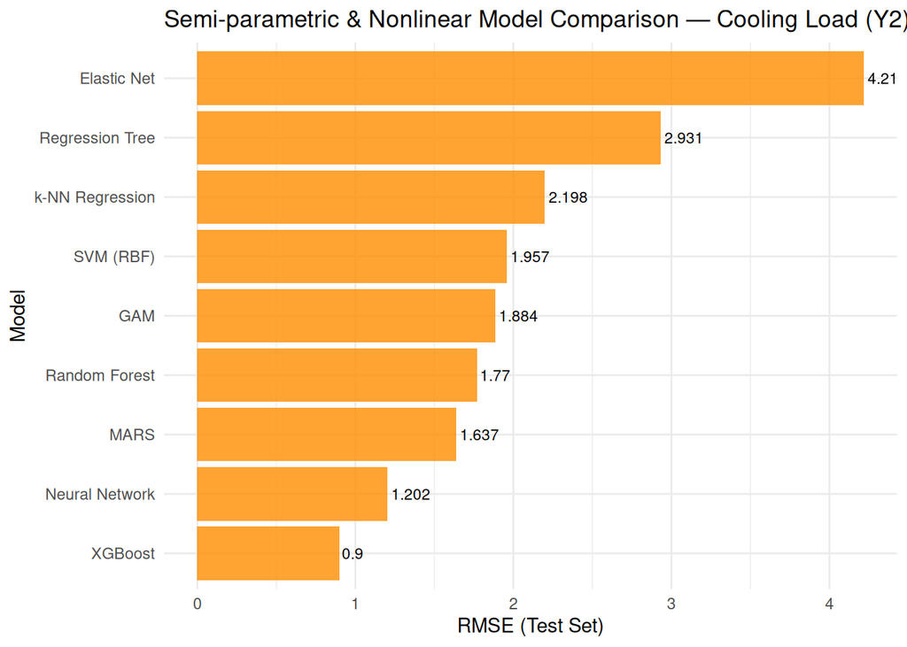

```r
p_rmse_y2 <- ggplot(results_y2, aes(x = reorder(Model, RMSE), y = RMSE)) +
  geom_col(fill = "darkorange", alpha = 0.8) +
  geom_text(aes(label = round(RMSE, 3)), hjust = -0.1, size = 3) +
  coord_flip() +
  labs(title = "Semi-parametric & Nonlinear Model Comparison — Cooling Load (Y2)",
       x = "Model", y = "RMSE (Test Set)") +
  theme_minimal()
ggsave(file.path(img_dir, "comparison_y2_rmse.png"),
       plot = p_rmse_y2, width = 10, height = 7, dpi = 150)
print(p_rmse_y2)
```

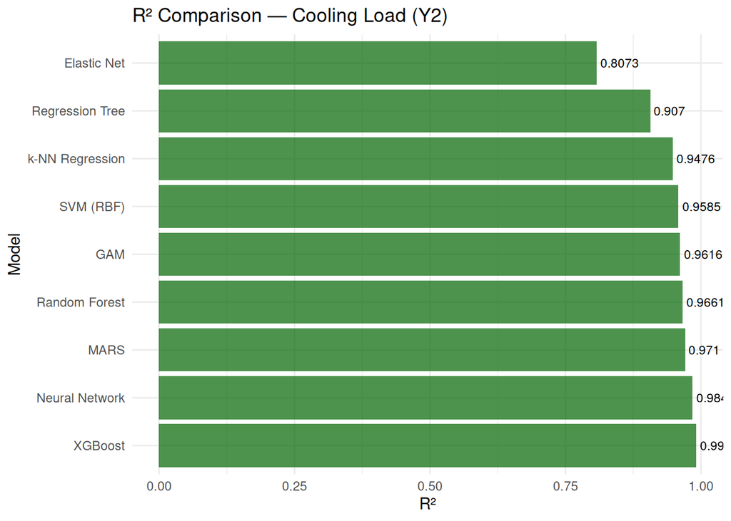

```r
p_r2_y2 <- ggplot(results_y2, aes(x = reorder(Model, -R2), y = R2)) +
  geom_col(fill = "darkgreen", alpha = 0.7) +
  geom_text(aes(label = round(R2, 4)), hjust = -0.1, size = 3) +
  coord_flip() +
  labs(title = "R² Comparison — Cooling Load (Y2)",
       x = "Model", y = "R²") +
  theme_minimal()
ggsave(file.path(img_dir, "comparison_y2_r2.png"),
       plot = p_r2_y2, width = 10, height = 7, dpi = 150)
print(p_r2_y2)
```